# Rank-normalized split-Rhat and relative efficiency estimates

### 4.2.5 Scaling one chain

Next, we investigate the sensitivity to detect if one of the chains has not converged to the same distribution as the others, but has lower marginal variance.

```r
conds <- expand.grid(
  iters = c(250, 1000, 4000),
  scale = c(0, 0.25, 0.5, 0.75, 1),
  rep = 1:10
)
res <- vector("list", nrow(conds))
chains = 4
for (i in 1:nrow(conds)) {
  iters <- conds[i, "iters"]
  scale <- conds[i, "scale"]
  rep <- conds[i, "rep"]
  r <- array(rnorm(iters * chains), c(iters, chains))
  r[, 1] <- r[, 1] * scale
  rs <- as.data.frame(monitor_extra(r))
  res[[i]] <- cbind(iters, scale, rep, rs)
}
res <- bind_rows(res)
```

We first look at the Rhat estimates:

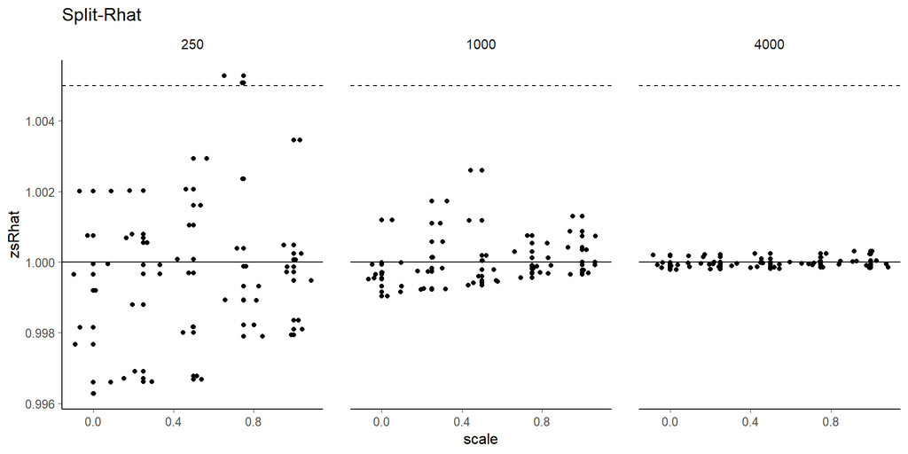

```r
ggplot(data = res, aes(y = zsRhat, x = scale)) +
  geom_point() +
  geom_jitter() +
  facet_grid(. ~ iters) +
  geom_hline(yintercept = 1.005, linetype = 'dashed') +
  geom_hline(yintercept = 1) +
  ggtitle('Split-Rhat')
```

**Result:** Split-Rhat is not able to detect scale differences between chains.

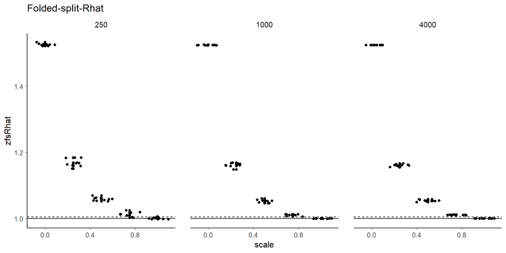

```r
ggplot(data = res, aes(y = zfsRhat, x = scale)) +
  geom_point() +
  geom_jitter() +
  facet_grid(. ~ iters) +
  geom_hline(yintercept = 1.005, linetype = 'dashed') +
  geom_hline(yintercept = 1) +
  ggtitle('Folded-split-Rhat')
```

**Result:** Folded-Split-Rhat focuses explicitly on scales and can thus detect scale differences.

**Result:** If we use a threshold of $1.01$, we can detect a chain with scale less than $3/4$ of the standard deviation of the others. If we use threshold of $1.1$, we can detect a chain with standard deviation less than $1/4$ of the standard deviation of the others.

Next, we look at the relative efficiency estimates:

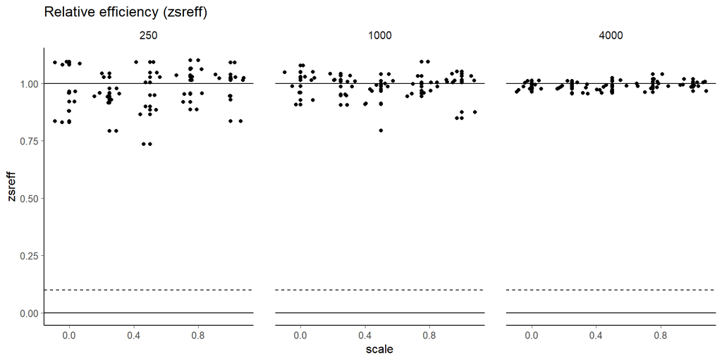

```r
ggplot(data = res, aes(y = zsreff, x = scale)) +
  geom_point() +
  geom_jitter() +
  facet_grid(. ~ iters) +
  geom_hline(yintercept = c(0,1)) +
  geom_hline(yintercept = 0.1, linetype = 'dashed') +
  ggtitle('Relative efficiency (zsreff)') +
  scale_y_continuous(breaks = seq(0, 1, by = 0.25))
```

**Result:** The relative efficiency of the mean does not see a problem as it focuses on location differences between chains.

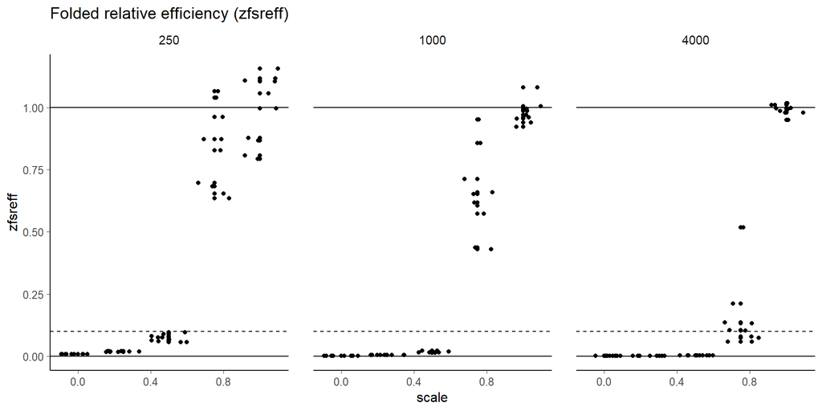

```r
ggplot(data = res, aes(y = zfsreff, x = scale)) +
  geom_point() +
  geom_jitter() +
  facet_grid(. ~ iters) +
  geom_hline(yintercept = c(0,1)) +
  geom_hline(yintercept = 0.1, linetype = 'dashed') +
  ggtitle('Folded relative efficiency (zfsreff)') +
  scale_y_continuous(breaks = seq(0, 1, by = 0.25))
```

**Result:** The relative efficiency of the standard deviation does see the problem as it focuses explicitely on the scale of the chains.

Rank plots can be used to visualize differences between chains. Here, we show rank plots for the case of 4 chains, 250 draws per chain, and with one chain having a standard deviation of 0.75 as opposed to a standard deviation of 1 for the other chains.

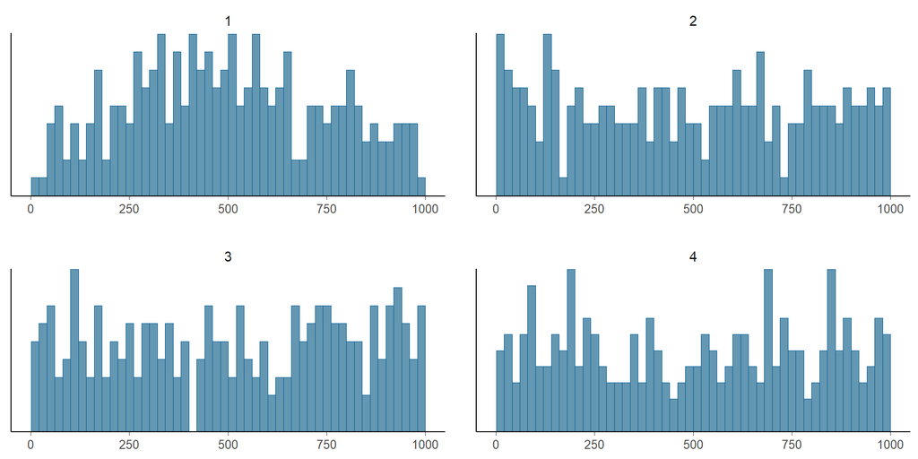

```r
iters = 250
chains = 4
scale = 0.75
r <- array(rnorm(iters * chains), c(iters, chains))
r[, 1] <- r[, 1] * scale
colnames(r) <- 1:4
mcmc_hist_r_scale(r)
```

## Appendix E: Cauchy: A distribution with infinite mean and variance

The classic split-Rhat is based on calculating within and between chain variances. If the marginal distribution of a chain is such that the variance is not defined (i.e. infinite), the classic split-Rhat is not well justified. In this section, we will use the Cauchy distribution as an example of such distribution. Also in cases where mean and variance are finite, the distribution can be far from Gaussian. Especially distributions with very long tails cause instability for variance and autocorrelation estimates. To alleviate these problems we will use Split-Rhat for rank-normalized draws.

The following Cauchy models are from Michael Betancourt’s case study [Fitting The Cauchy Distribution](https://betanalpha.github.io/assets/case_studies/fitting_the_cauchy.html)

### 4.2.6 Nominal parameterization of Cauchy

We already looked at the nominal Cauchy model with direct parameterization in the main text, but for completeness, we take a closer look using different variants of the diagnostics.

```r
writeLines(readLines("cauchy_nom.stan"))
```

```
parameters {
  vector[50] x;
}

model {
  x ~ cauchy(0, 1);
}

generated quantities {
  real I = fabs(x[1]) < 1 ? 1 : 0;
}
```

#### 4.2.6.1 Default Stan options

Run the nominal model:

```r
fit_nom <- stan(file = 'cauchy_nom.stan', seed = 7878, refresh = 0)
```

```
Warning: There were 1233 transitions after warmup that exceeded the maximum treedepth. Increase max_treedepth above 10. See
http://mc-stan.org/misc/warnings.html#maximum-treedepth-exceeded
```

```
Warning: Examine the pairs() plot to diagnose sampling problems
```

Trace plots for the first parameter look wild with occasional large values:

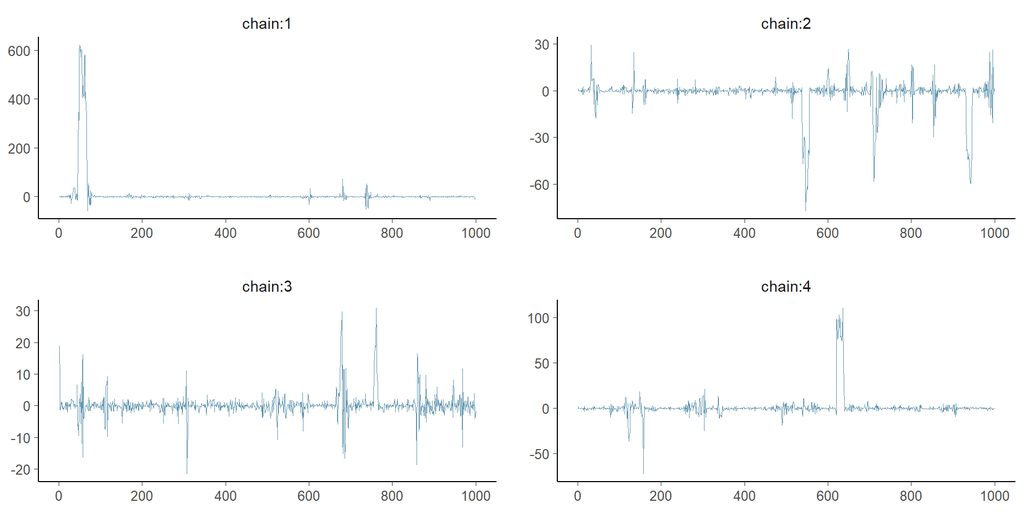

```r
samp <- as.array(fit_nom)
mcmc_trace(samp[, , 1])
```

Let’s check Rhat and relative efficiency diagnostics.

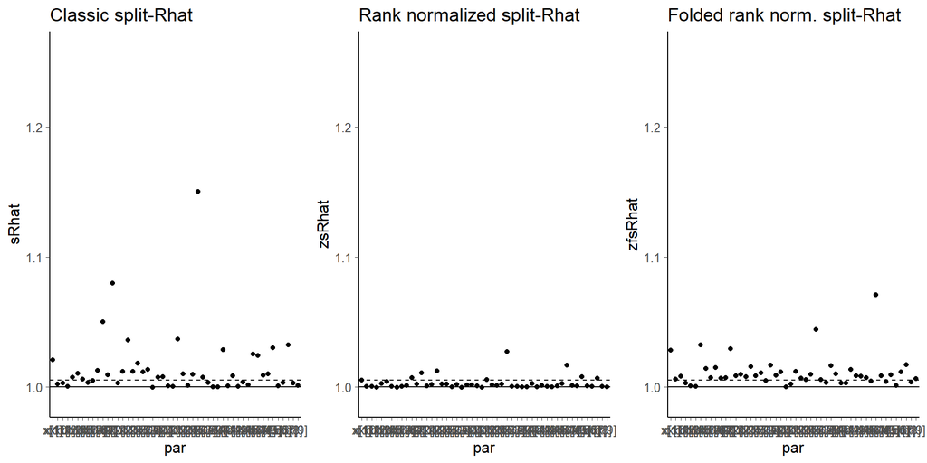

```r
res <- monitor_extra(samp[, , 1:50])
which_min_eff <- which.min(res$zsreff)
plot_rhat(res)
```

For one parameter, Rhats exceed the classic threshold of 1.1. Depending on the Rhat estimate, a few others also exceed the threshold of 1.01. The rank normalized split-Rhat has several values over 1.01. Please note that the classic split-Rhat is not well defined in this example, because mean and variance of the Cauchy distribution are not finite.

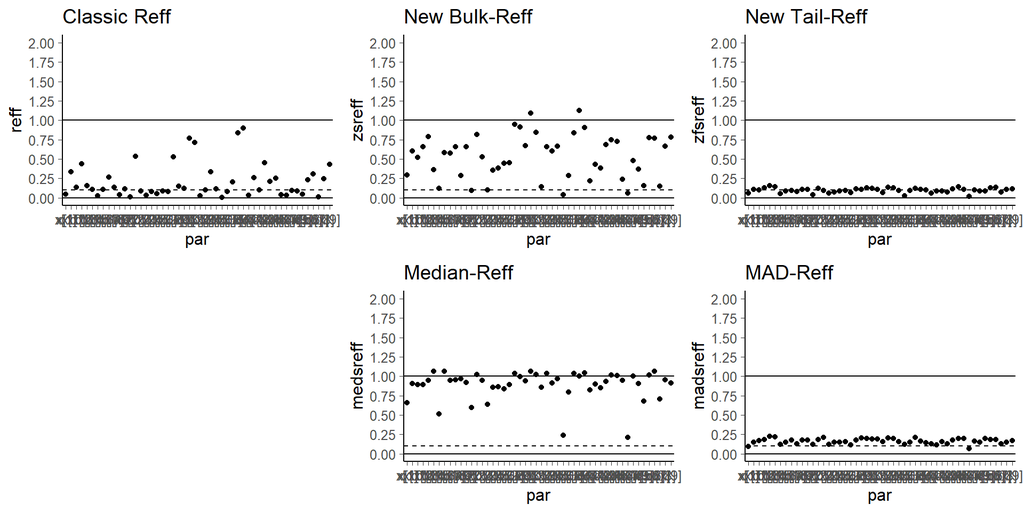

```r
plot_reff(res)
```

Both classic and new relative efficiency estimates have several near zero values, and so the overall sample shouldn’t be trusted.

**Result:** Relative efficiency is more sensitive than (rank-normalized) split-Rhat to detect problems of slow mixing.

We also check the log posterior value `lp__` and find out that the relative efficiency is worryingly low.

```r
res <- monitor_extra(samp[, , 51:52])
cat('lp__: Bulk-R_eff = ', round(res['lp__', 'zsreff'], 2), '\n')
```

```
lp__: Bulk-R_eff =  0.03
```

```r
cat('lp__: Tail-R_eff = ', round(res['lp__', 'zfsreff'], 2), '\n')
```

```
lp__: Tail-R_eff =  0.12
```

We can further analyze potential problems using local relative efficiency and rank plots. We examine x[36], which has the smallest bulk relative efficiency of 0.03.

We examine the relative efficiency in different parts of the posterior by computing the relative efficiency of small interval probability estimates (see Section Relative efficiency of small interval probability estimates). Each interval contains $1/k$ of the draws (e.g., with $k=20$). The small interval efficiency measures mixing of an indicator function which indicates when the values are inside the specific small interval. This gives us a local efficiency measure which does not depend on the shape of the distribution.

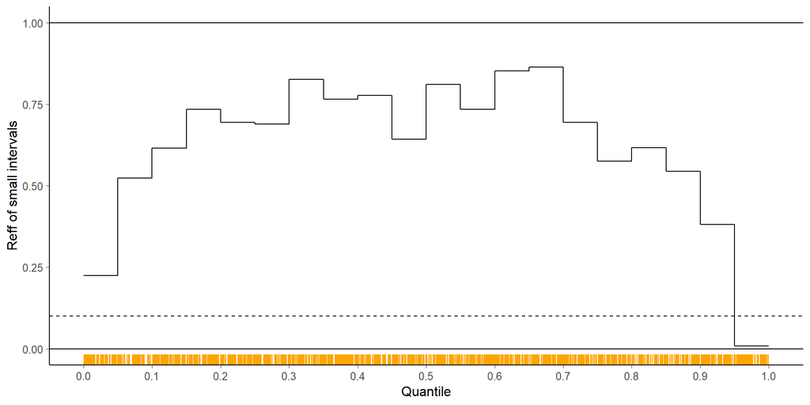

```r
plot_local_reff(fit = fit_nom, par = which_min_eff, nalpha = 20)
```

We see that the efficiency is worryingly low in the tails (which is caused by slow mixing in long tails of Cauchy). Orange ticks show draws that exceeded the maximum treedepth.

An alternative way to examine the relative efficiency in different parts of the posterior is to compute relative efficiency for quantiles (see Section Relative efficiency of quantiles). Each interval has a specified proportion of draws, and the efficiency measures mixing of an indicator function’s results which indicate when the values are inside the specific interval.

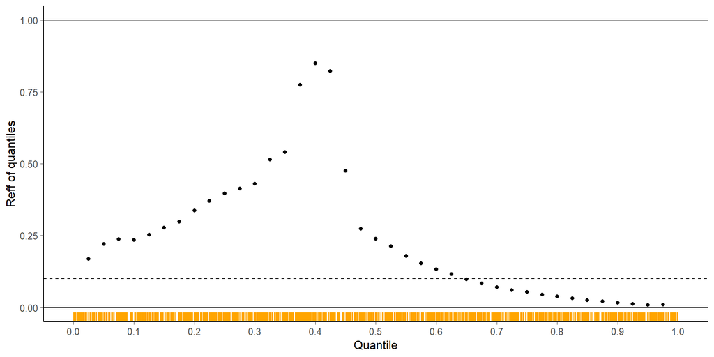

```r
plot_quantile_reff(fit = fit_nom, par = which_min_eff, nalpha = 40)
```

We see that the efficiency is worryingly low in the tails (which is caused by slow mixing in long tails of Cauchy). Orange ticks show draws that exceeded the maximum treedepth.

We can further analyze potential problems using rank plots, from which we clearly see differences between chains.

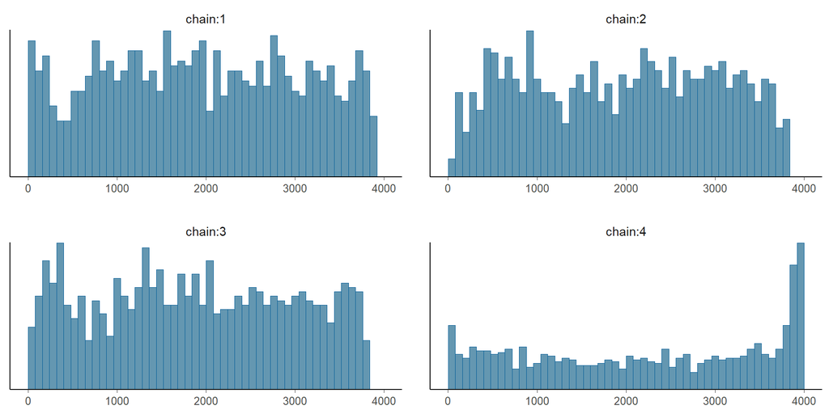

```r
xmin <- paste0("x[", which_min_eff, "]")
mcmc_hist_r_scale(samp[, , xmin])
```

#### 4.2.6.2 Default Stan options + increased maximum treedepth

We can try to improve the performance by increasing `max_treedepth` to $20$:

```r
fit_nom_td20 <- stan(
  file = 'cauchy_nom.stan', seed = 7878,
  refresh = 0, control = list(max_treedepth = 20)
)
```

Trace plots for the first parameter still look wild with occasional large values.

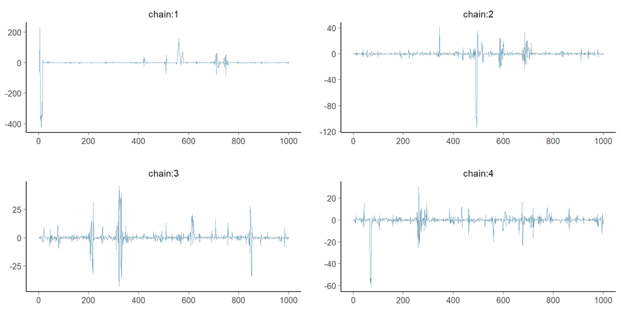

```r
samp <- as.array(fit_nom_td20)
mcmc_trace(samp[, , 1])
```

```r
res <- monitor_extra(samp[, , 1:50])
which_min_eff <- which.min(res$zsreff)
```

We check the diagnostics for all $x$.

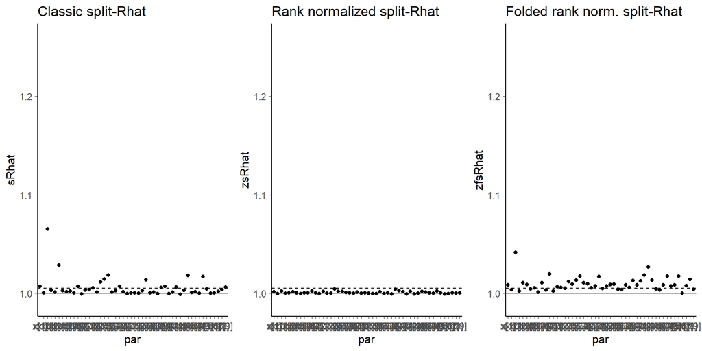

```r
plot_rhat(res)
```

All Rhats are below $1.1$, but many are over $1.01$. Classic split-Rhat has more variation than the rank normalized Rhat (note that the former is not well defined). The folded rank normalized Rhat shows that there is still more variation in the scale than in the location between different chains.

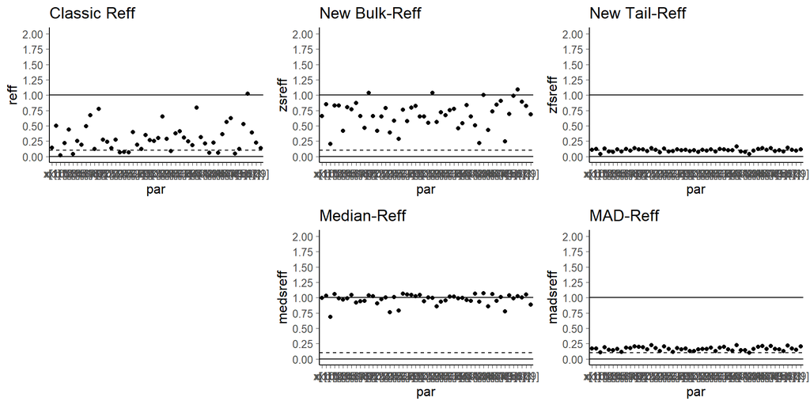

```r
plot_reff(res)
```

Some classic Reff’s are close to zero. If we wouldn’t realize that the variance is infinite, we might try to run longer chains, but in case of an infinite variance, zero efficiency is the truth and longer chains won’t help with that. However other quantities can be well defined, and that’s why it is useful to also look at the rank normalized version as a generic transformation to achieve finite mean and variance. The smallest bulk-$R_{\rm eff}$ are around $0.25$, which is not that bad. The smallest median-$R_{\rm eff}$s are larger than $0.5$, that is we are able to estimate the median efficiently. However, many tail-$R_{\rm eff}$s are small indicating problemes for estimating the scale of the posterior.

**Result:** The rank normalized relative efficiency is more stable than classic relative efficiency, which is not well defined for the Cauchy distribution.

**Result:** It is useful to look at both bulk and tail relative efficiencies.

We check also `lp__`. Although increasing `max_treedepth` improved efficiency for bulk of `x`, the efficiency for `lp__` didn’t change.

```r
res <- monitor_extra(samp[, , 51:52])
cat('lp__: Bulk-R_eff =', round(res['lp__', 'zsreff'], 2), '\n')
```

```
lp__: Bulk-R_eff = 0.06
```

```r
cat('lp__: Tail-R_eff =', round(res['lp__', 'zfsreff'], 2), '\n')
```

```
lp__: Tail-R_eff = 0.18
```

We examine the relative efficiency in different parts of the posterior by computing the relative efficiency of small interval probability estimates.

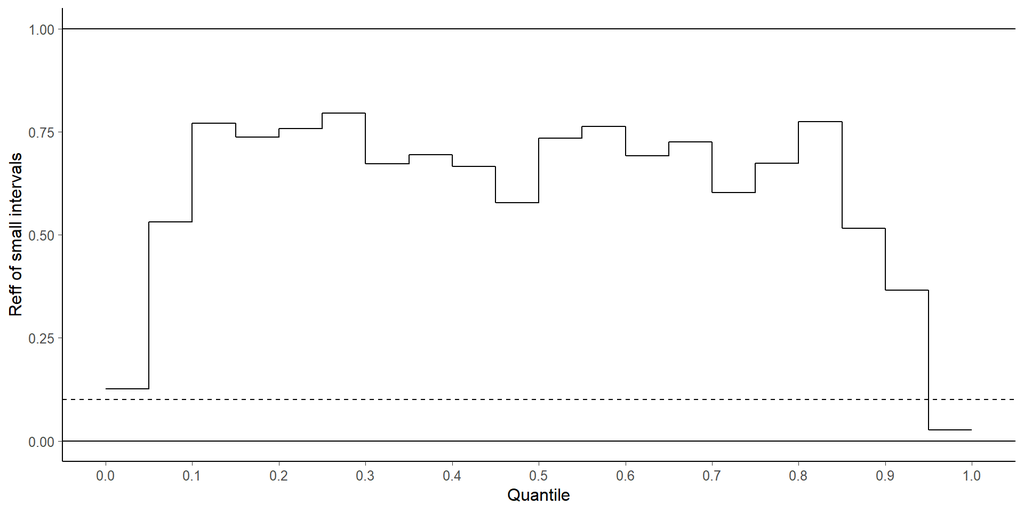

```r
plot_local_reff(fit = fit_nom_td20, par = which_min_eff, nalpha = 20)
```

It seems that increasing `max_treedepth` has not much improved the efficiency in the tails. We also examine the relative efficiency of different quantile estimates.

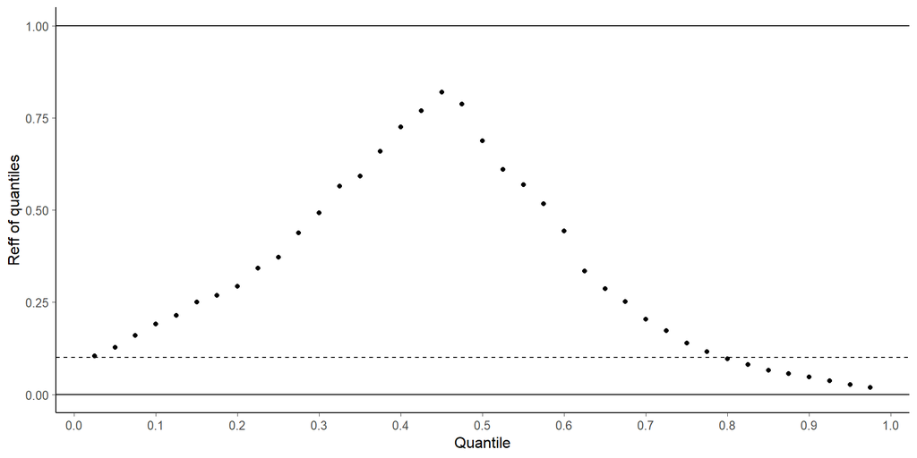

```r
plot_quantile_reff(fit = fit_nom_td20, par = which_min_eff, nalpha = 40)
```

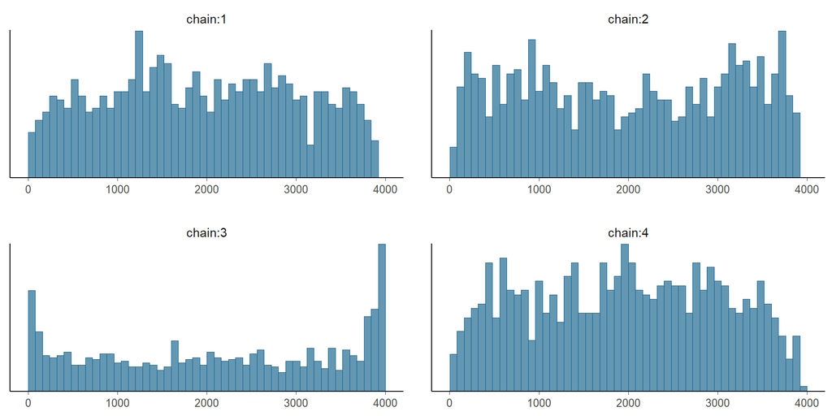

```r
xmin <- paste0("x[", which_min_eff, "]")
mcmc_hist_r_scale(samp[, , xmin])
```

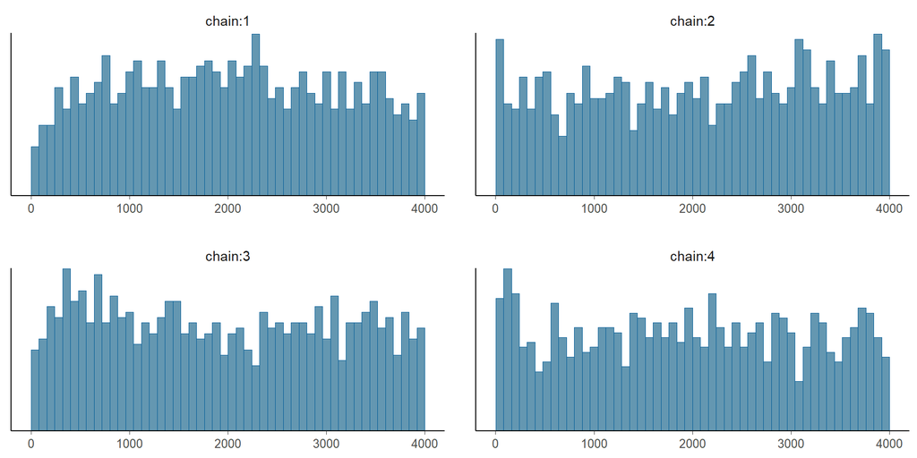

```r
mcmc_hist_r_scale(samp[, , "lp__"])
```

#### 4.2.6.3 Default Stan options + increased maximum treedepth + longer chains

Let’s try running 8 times longer chains.

```r
fit_nom_td20l <- stan(
  file = 'cauchy_nom.stan', seed = 7878,
  refresh = 0, control = list(max_treedepth = 20),
  warmup = 1000, iter = 9000
)
```

Trace plots for the first parameter still look wild with occasional large values.

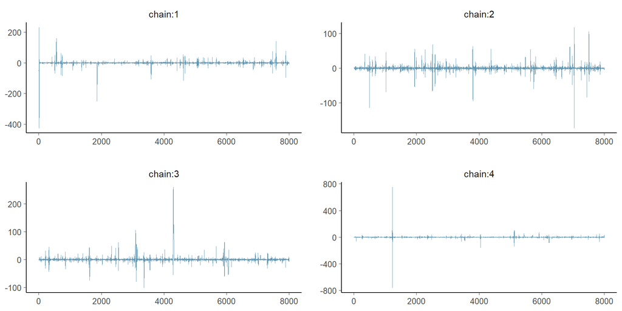

```r
samp <- as.array(fit_nom_td20l)
mcmc_trace(samp[, , 1])
```

```r
res <- monitor_extra(samp[, , 1:50])
which_min_eff <- which.min(res$zsreff)
```

Let’s check the diagnostics for all $x$.

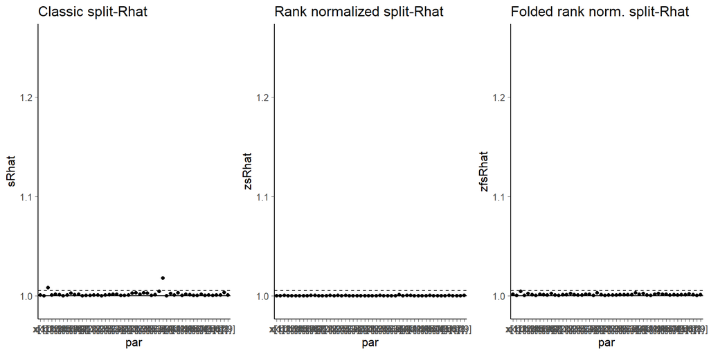

```r
plot_rhat(res)
```

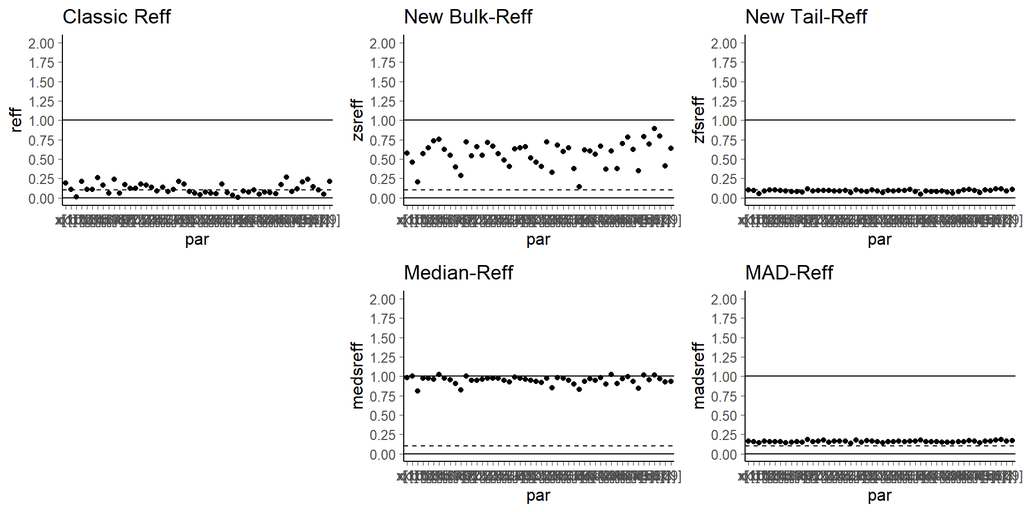

```r
plot_reff(res)
```

Most classic $R_{\rm eff}$s are close to zero. Running longer chains just made most classic $R_{\rm eff}$s even smaller.

The smallest bulk-$R_{\rm eff}$ are around $0.25$, which is not that bad. The smallest median-$R_{\rm eff}$’s are larger than $0.75$, that is we are able to estimate the median efficiently. However, many tail-$R_{\rm eff}$’s are small indicating problmes for estimating the scale of the posterior.

**Result:** The rank normalized relative efficiency is more stable than classic relative efficiency even for very long chains.

**Result:** It is useful to look at both bulk and tail relative efficiencies.

We also check `lp__`. Although increasing the number of iterations improved efficiency for the bulk of the $x$, the efficiency for `lp__` didn’t change.

```r
res <- monitor_extra(samp[, , 51:52])
cat('lp__: Bulk-R_eff =', round(res['lp__', 'zsreff'], 2), '\n')
```

```
lp__: Bulk-R_eff = 0.04
```

```r
cat('lp__: Tail-R_eff =', round(res['lp__', 'zfsreff'], 2), '\n')
```

```
lp__: Tail-R_eff = 0.1
```

We examine the relative efficiency in different parts of the posterior by computing the relative efficiency of small interval probability estimates.

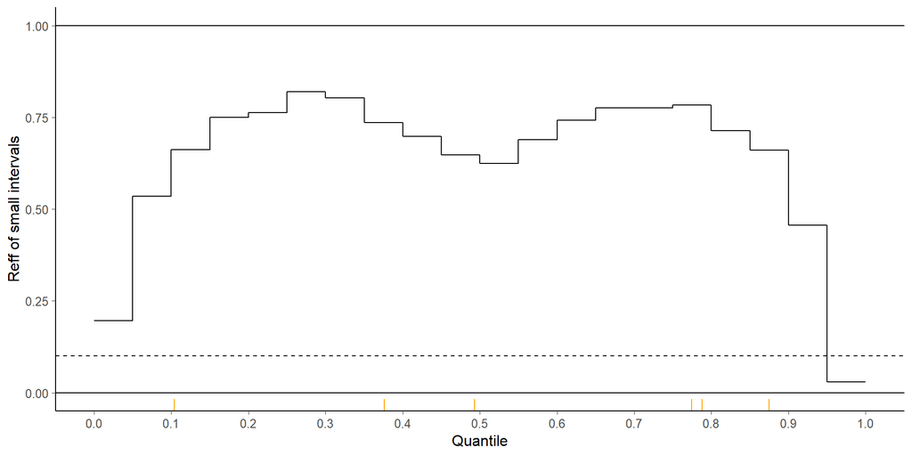

```r
plot_local_reff(fit = fit_nom_td20l, par = which_min_eff, nalpha = 20)
```

Increasing the chain length did not seem to change the relative efficiency. With more draws from the longer chains we can use a finer resolution for the local efficiency estimates.

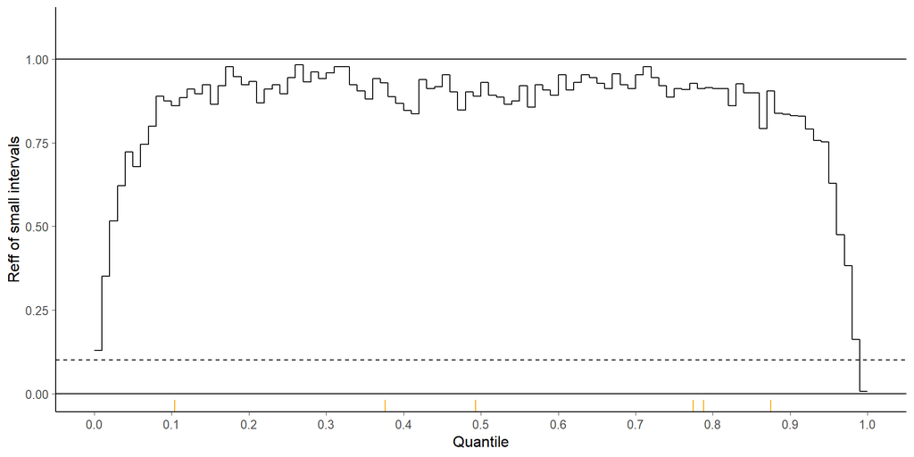

```r
plot_local_reff(fit = fit_nom_td20l, par = which_min_eff, nalpha = 100)
```

The efficiency far in the tails is worryingly low. This was more difficult to see previously with less draws from the tails. We see similar problems in the plot of relative efficiency of quantiles.

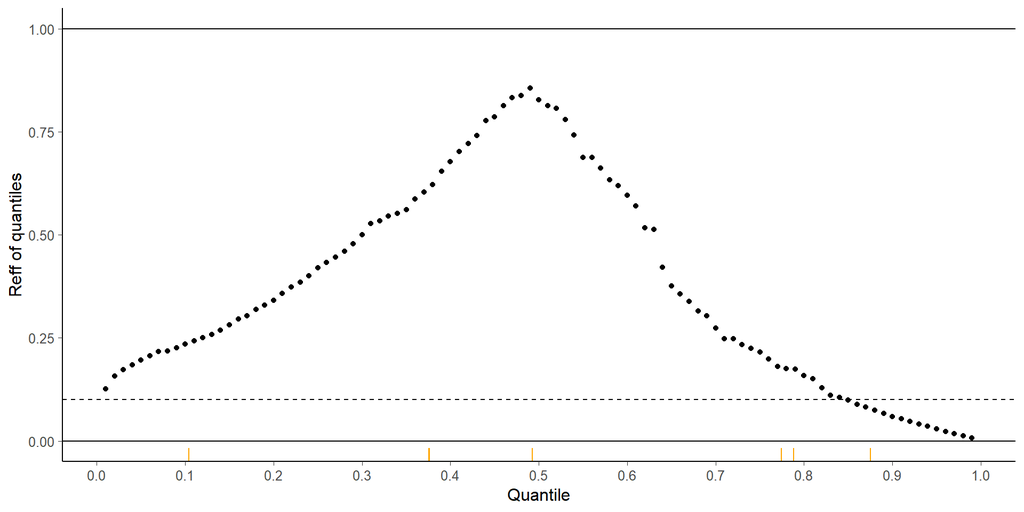

```r
plot_quantile_reff(fit = fit_nom_td20l, par = which_min_eff, nalpha = 100)
```

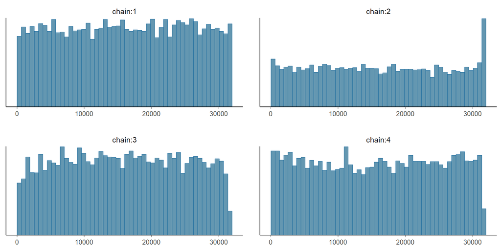

```r
xmin <- paste0("x[", which_min_eff, "]")
mcmc_hist_r_scale(samp[, , xmin])
```

Increasing the number of iterations couldn’t remove the mixing problems at the tails. The mixing problem is inherent to the nominal parameterization of Cauchy distribution.

### 4.2.7 First alternative parameterization of the Cauchy distribution

Next, we examine an alternative parameterization and consider the Cauchy distribution as a scale mixture of Gaussian distributions. The model has two parameters and the Cauchy distributed $x$ can be computed from those. In addition to improved sampling performance, the example illustrates that focusing on diagnostics matters.

```r
writeLines(readLines("cauchy_alt_1.stan"))
```

```
parameters {
  vector[50] x_a;
  vector<lower=0>[50] x_b;
}

transformed parameters {
  vector[50] x = x_a ./ sqrt(x_b);
}

model {
  x_a ~ normal(0, 1);
  x_b ~ gamma(0.5, 0.5);
}

generated quantities {
  real I = fabs(x[1]) < 1 ? 1 : 0;
}
```

We run the alternative model:

```r
fit_alt1 <- stan(file='cauchy_alt_1.stan', seed=7878, refresh = 0)
```

There are no warnings and the sampling is much faster.

```r
samp <- as.array(fit_alt1)
res <- monitor_extra(samp[, , 101:150])
which_min_eff <- which(res$zsreff == min(res$zsreff))
```

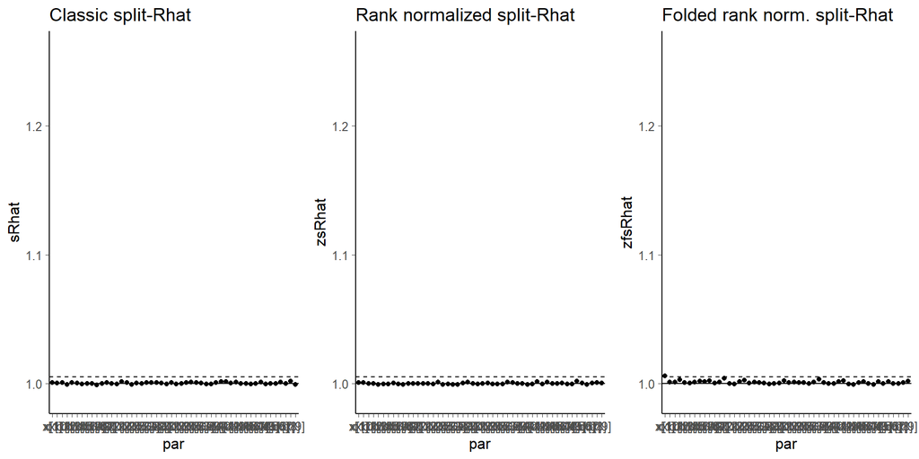

```r
plot_rhat(res)
```

All Rhats are below $1.01$. Classic split-Rhat’s also look good even though they are not well defined for the Cauchy distribution.

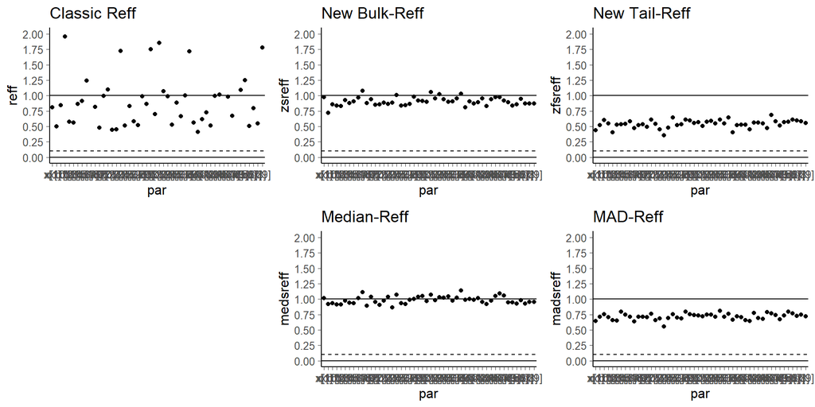

```r
plot_reff(res)
```

**Result:** Rank normalized R_eff’s have less variation than classic one which is not well defined for Cauchy.

We check `lp__`:

```r
res <- monitor_extra(samp[, , 151:152])
cat('lp__: Bulk-R_eff =', round(res['lp__', 'zsreff'], 2), '\n')
```

```
lp__: Bulk-R_eff = 0.33
```

```r
cat('lp__: Tail-R_eff =', round(res['lp__', 'zfsreff'], 2), '\n')
```

```
lp__: Tail-R_eff = 0.59
```

The relative efficiencies for `lp__` are also much better than with the nominal parameterization.

We examine the relative efficiency in different parts of the posterior by computing the relative efficiency of small interval probability estimates.

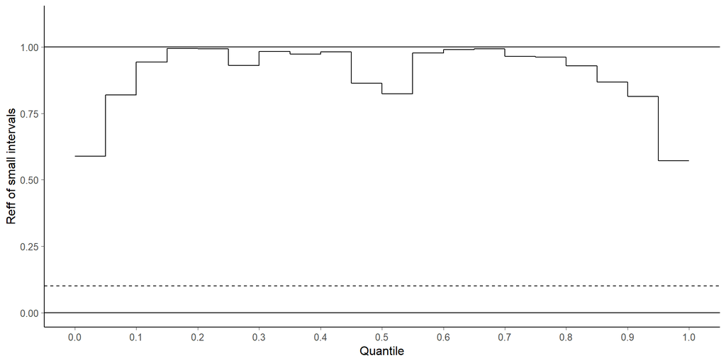

```r
plot_local_reff(fit = fit_alt1, par = 100 + which_min_eff, nalpha = 20)
```

The relative efficiency is good in all parts of the posterior. We also examine the relative efficiency of different quantile estimates.

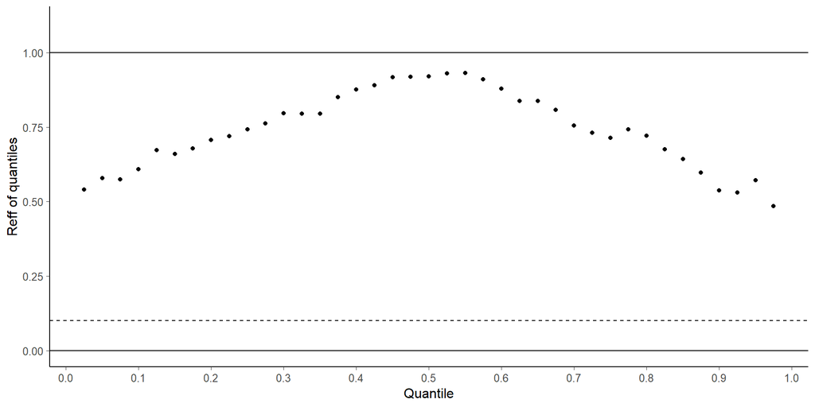

```r
plot_quantile_reff(fit = fit_alt1, par = 100 + which_min_eff, nalpha = 40)
```

We compare the mean relative efficiencies of the underlying parameters in the new parameterization and the actual $x$ we are interested in.

```r
res <- monitor_extra(samp[, , 101:150])
res1 <- monitor_extra(samp[, , 1:50])
res2 <- monitor_extra(samp[, , 51:100])
```

```r
cat('Mean bulk-R_eff for x =' , round(mean(res[, 'zsreff']), 2), '\n')
```

```
Mean bulk-R_eff for x = 0.91
```

```r
cat('Mean tail-R_eff for x =' , round(mean(res[, 'zfsreff']), 2), '\n')
```

```
Mean tail-R_eff for x = 0.54
```

```r
cat('Mean bulk-R_eff for x_a =' , round(mean(res1[, 'zsreff']), 2), '\n')
```

```
Mean bulk-R_eff for x_a = 0.99
```

```r
cat('Mean bulk-R_eff for x_b =' , round(mean(res2[, 'zsreff']), 2), '\n')
```

```
Mean bulk-R_eff for x_b = 0.69
```

**Result:** We see that the relative efficiency of the interesting $x$ can be different from the relative efficiency of the parameters $x_a$ and $x_b$ that we used to compute it.

The rank plot visualisation of x[10], which has the smallest relative efficiency of 0.72 among the $x$ looks better than for the nominal parameterization.

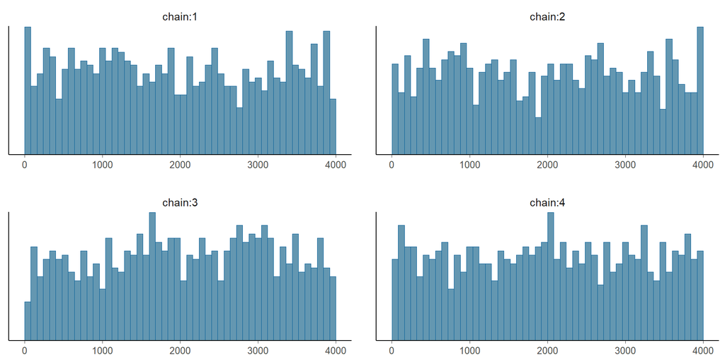

```r
xmin <- paste0("x[", which_min_eff, "]")
mcmc_hist_r_scale(samp[, , xmin])
```

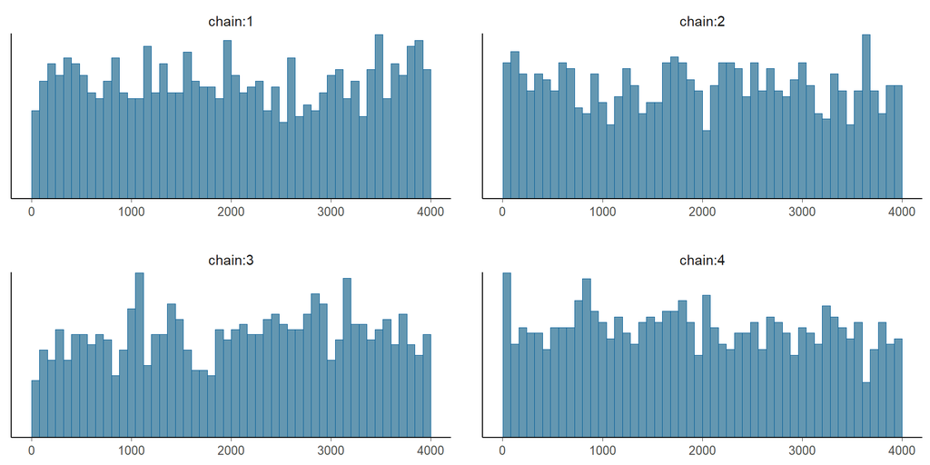

```r
mcmc_hist_r_scale(samp[, , "lp__"])
```

### 4.2.8 Another alternative parameterization of the Cauchy distribution

Another alternative parameterization is obtained by a univariate transformation as shown in the following code (see also the 3rd alternative in Michael Betancourt’s case study).

```r
writeLines(readLines("cauchy_alt_3.stan"))
```

```
parameters {
  vector<lower=0, upper=1>[50] x_tilde;
}

transformed parameters {
vector[50] x = tan(pi() * (x_tilde - 0.5));
}

model {
  // Implicit uniform prior on x_tilde
}

generated quantities {
  real I = fabs(x[1]) < 1 ? 1 : 0;
}
```

We run the alternative model:

```r
fit_alt3 <- stan(file='cauchy_alt_3.stan', seed=7878, refresh = 0)
```

There are no warnings, and the sampling is much faster than for the nominal model.

```r
samp <- as.array(fit_alt3)
res <- monitor_extra(samp[, , 51:100])
which_min_eff <- which(res$zsreff == min(res$zsreff))
```

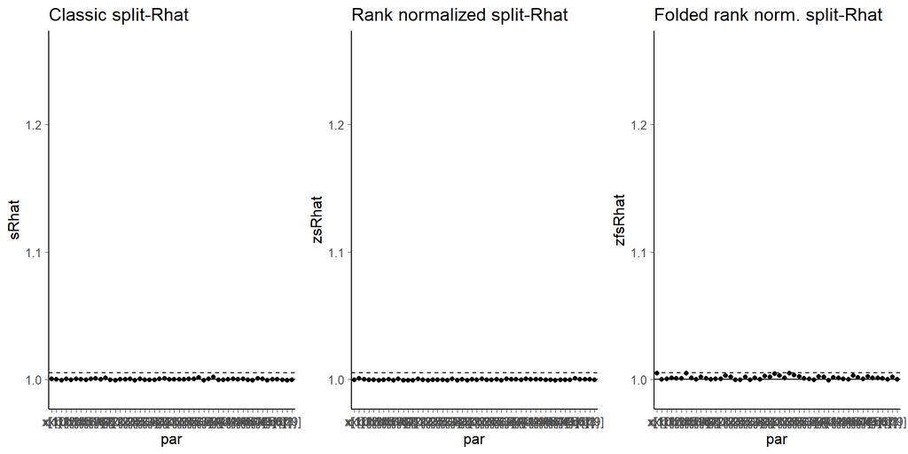

```r
plot_rhat(res)
```

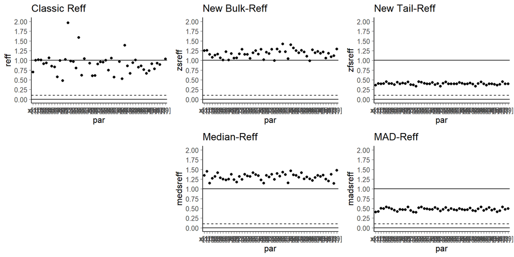

```r
plot_reff(res)
```

**Result:** Rank normalized relative efficiencies have less variation than classic ones. Bulk-$R_{\rm eff}$ and median-$R_{\rm eff}$ are slightly larger than 1, which is possible for antithetic Markov chains which have negative correlation for odd lags.

We also take a closer look at the `lp__` value:

```r
res <- monitor_extra(samp[, , 101:102])
cat('lp__: Bulk-R_eff =', round(res['lp__', 'zsreff'], 2), '\n')
```

```
lp__: Bulk-R_eff = 0.37
```

```r
cat('lp__: Tail-R_eff =', round(res['lp__', 'zfsreff'], 2), '\n')
```

```
lp__: Tail-R_eff = 0.56
```

The relative efficiency for these are also much better than with the nominal parameterization.

We examine the relative efficiency in different parts of the posterior by computing the relative efficiency of small interval probability estimates.

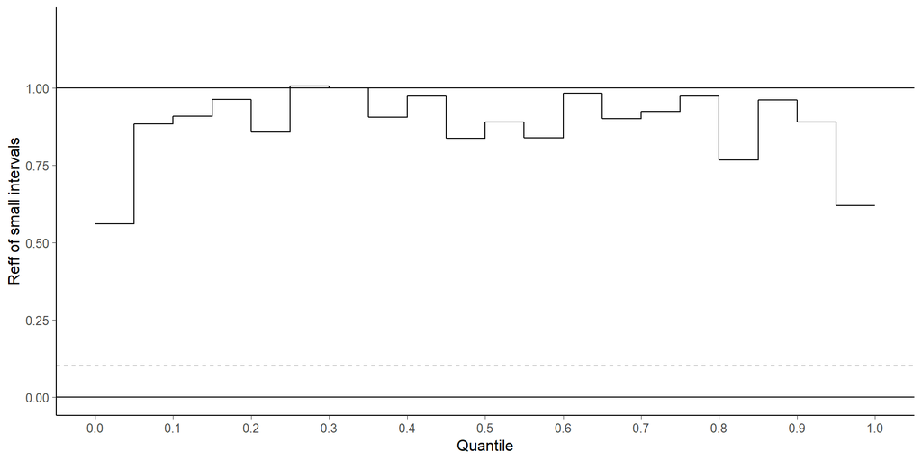

```r
plot_local_reff(fit = fit_alt3, par = 50 + which_min_eff, nalpha = 20)
```

We examine also the relative efficiency of different quantile estimates.

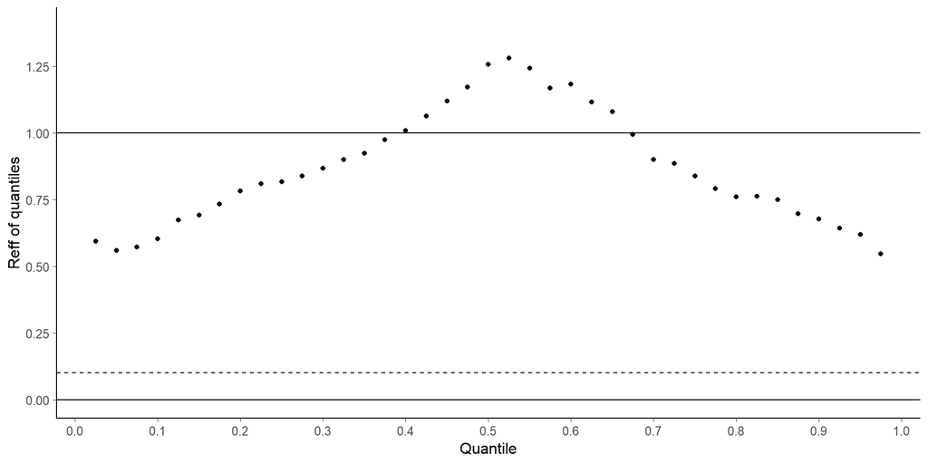

```r
plot_quantile_reff(fit = fit_alt3, par = 50 + which_min_eff, nalpha = 40)
```

The relative efficiency in tails is worse than for the first alternative parameterization, although it’s still better than for the nominal parameterization.

We compare the mean relative efficiency of the underlying parameter in the new parameterization and the actually Cauchy distributed $x$ we are interested in.

```r
res <- monitor_extra(samp[, , 51:100])
res1 <- monitor_extra(samp[, , 1:50])
cat('Mean bulk-Reff for x =' , round(mean(res[, 'zsreff']), 2), '\n')
```

```
Mean bulk-Reff for x = 1.18
```

```r
cat('Mean tail-Reff for x =' , round(mean(res[, 'zfsreff']), 2), '\n')
```

```
Mean tail-Reff for x = 0.4
```

```r
cat('Mean bulk-Reff for x_tilde =' , round(mean(res1[, 'zsreff']), 2), '\n')
```

```
Mean bulk-Reff for x_tilde = 1.18
```

```r
cat('Mean tail-Reff for x_tilde =' , round(mean(res1[, 'zfsreff']), 2), '\n')
```

```
Mean tail-Reff for x_tilde = 0.4
```

The Rank plot visualisation of x[45], which has the smallest relative efficiency of 0.99 among the $x$ reveals shows good efficiency, similar to the results for `lp__`.

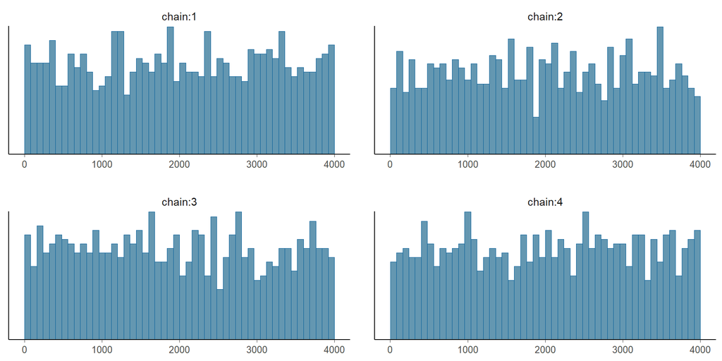

```r
xmin <- paste0("x[", which_min_eff, "]")
mcmc_hist_r_scale(samp[, , xmin])
```

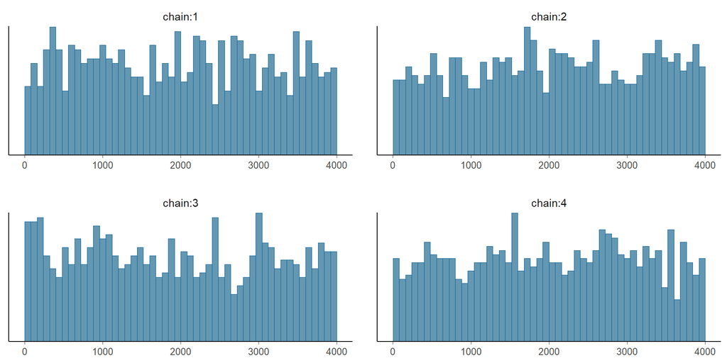

```r
mcmc_hist_r_scale(samp[, , "lp__"])
```

### 4.2.9 Half-Cauchy distribution with nominal parameterization

Half-Cauchy priors are common and, for example, in Stan usually set using the nominal parameterization. However, when the constraint `<lower=0>` is used, Stan does the sampling automatically in the unconstrained `log(x)` space, which changes the geometry crucially.

```r
writeLines(readLines("half_cauchy_nom.stan"))
```

```
parameters {
  vector<lower=0>[50] x;
}

model {
  x ~ cauchy(0, 1);
}

generated quantities {
  real I = fabs(x[1]) < 1 ? 1 : 0;
}
```

We run the half-Cauchy model with nominal parameterization (and positive constraint).

```r
fit_half_nom <- stan(file = 'half_cauchy_nom.stan', seed = 7878, refresh = 0)
```

There are no warnings and the sampling is much faster than for the full Cauchy distribution with nominal parameterization.

```r
samp <- as.array(fit_half_nom)
res <- monitor_extra(samp[, , 1:50])
which_min_eff <- which.min(res$zsreff)
```

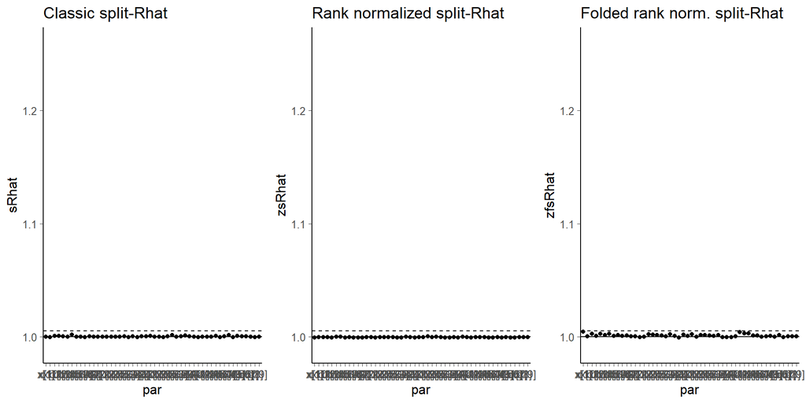

```r
plot_rhat(res)
```

All Rhats are below $1.01$. Classic split-Rhats also look good even though they are not well defined for the half-Cauchy distribution.

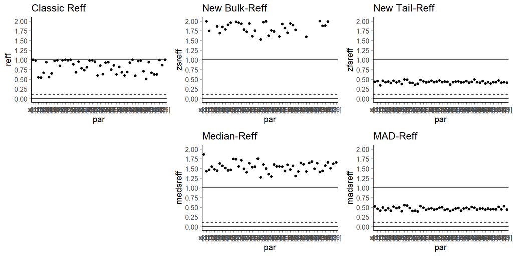

```r
plot_reff(res)
```

**Result:** Rank normalized Reffs have less variation than classic ones. Some Bulk-$R_{\rm eff}$ and median-$R_{\rm eff}$ are larger than 1, which is possible for antithetic Markov chains which have negative correlation for odd lags.

Due to the `<lower=0>` constraint, the sampling was made in the `log(x)` space, and we can also check the performance in that space.

```r
res <- monitor_extra(log(samp[, , 1:50]))
```

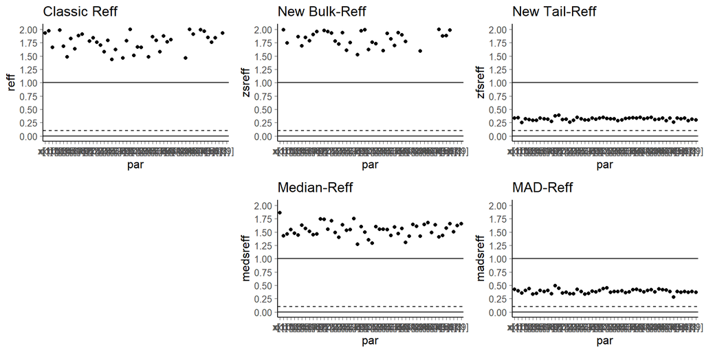

```r
plot_reff(res)
```

$\log(x)$ is quite close to Gaussian, and thus classic Reff is also close to rank normalized Reff which is exactly the same as for the original $x$ as rank normalization is invariant to bijective transformations.

**Result:** The rank normalized relative efficiency is close to the classic relative efficiency for transformations which make the distribution close to Gaussian.

We examine the relative efficiency in different parts of the posterior by computing the relative efficiency of small interval probability estimates.

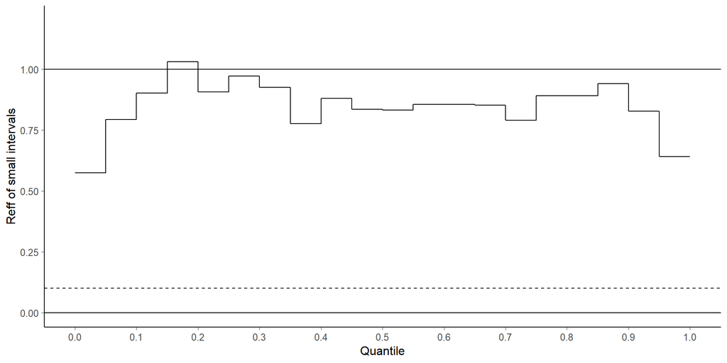

```r
plot_local_reff(fit = fit_half_nom, par = which_min_eff, nalpha = 20)
```

The relative efficiency is good overall, with only a small dip in tails. We can also examine the relative efficiency of different quantile estimates.

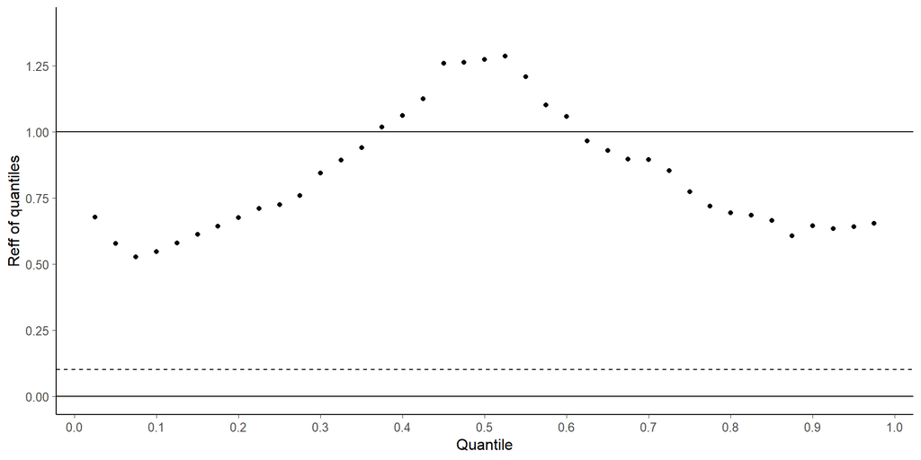

```r
plot_quantile_reff(fit = fit_half_nom, par = which_min_eff, nalpha = 40)
```

The rank plot visualisation of x[29], which has the smallest relative efficiency of 1.53 among $x$, looks good.

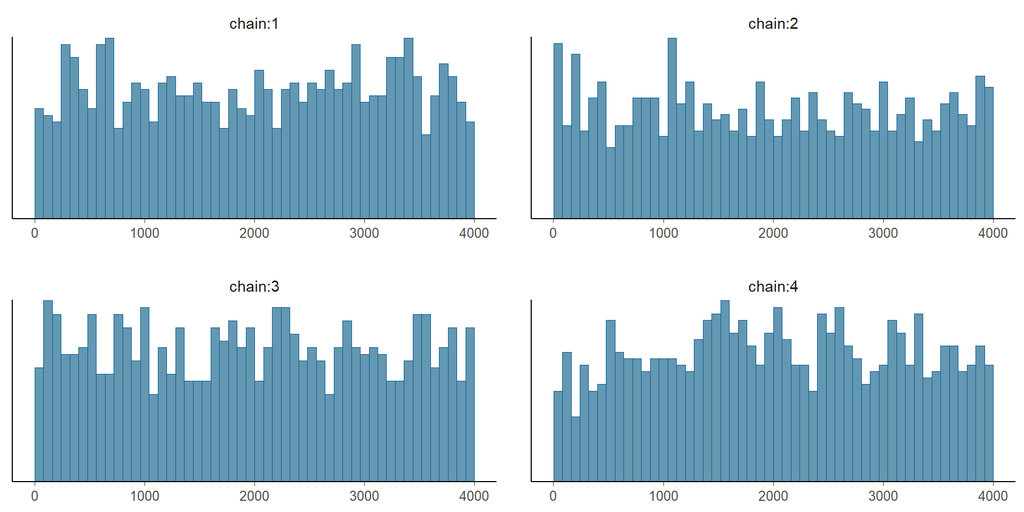

```r
xmin <- paste0("x[", which_min_eff, "]")
mcmc_hist_r_scale(samp[, , xmin])
```

The rank plot visualisation of `lp__` reveals some small differences in the scales, but it’s difficult to know whether this small variation from uniform is relevant.

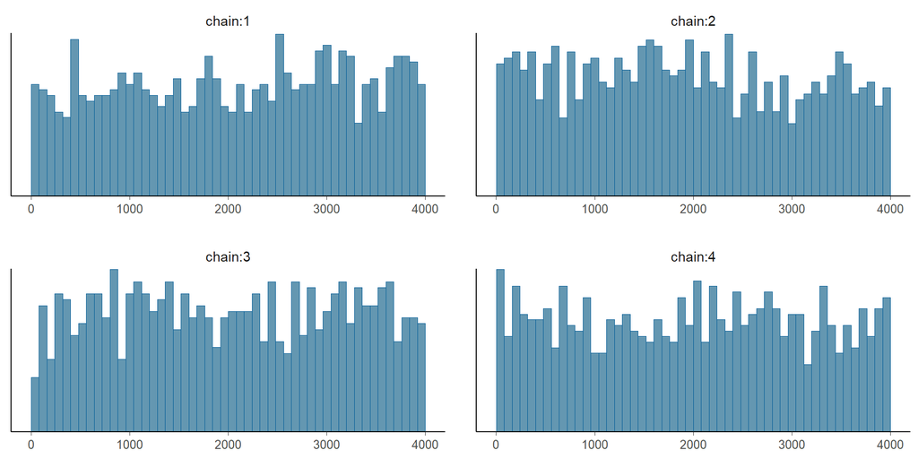

```r
mcmc_hist_r_scale(samp[, , "lp__"])
```

### 4.2.10 Alternative parameterization of the half-Cauchy distribution

```r
writeLines(readLines("half_cauchy_alt.stan"))
```

```
parameters {
  vector<lower=0>[50] x_a;
  vector<lower=0>[50] x_b;
}

transformed parameters {
  vector[50] x = x_a .* sqrt(x_b);
}

model {
  x_a ~ normal(0, 1);
  x_b ~ inv_gamma(0.5, 0.5);
}

generated quantities {
  real I = fabs(x[1]) < 1 ? 1 : 0;
}
```

Run half-Cauchy with alternative parameterization

```r
fit_half_reparam <- stan(
  file = 'half_cauchy_alt.stan', seed = 7878, refresh = 0
)
```

There are no warnings and the sampling is as fast for the half-Cauchy nominal model.

```r
samp <- as.array(fit_half_reparam)
res <- monitor_extra(samp[, , 101:150])
which_min_eff <- which.min(res$zsreff)
```

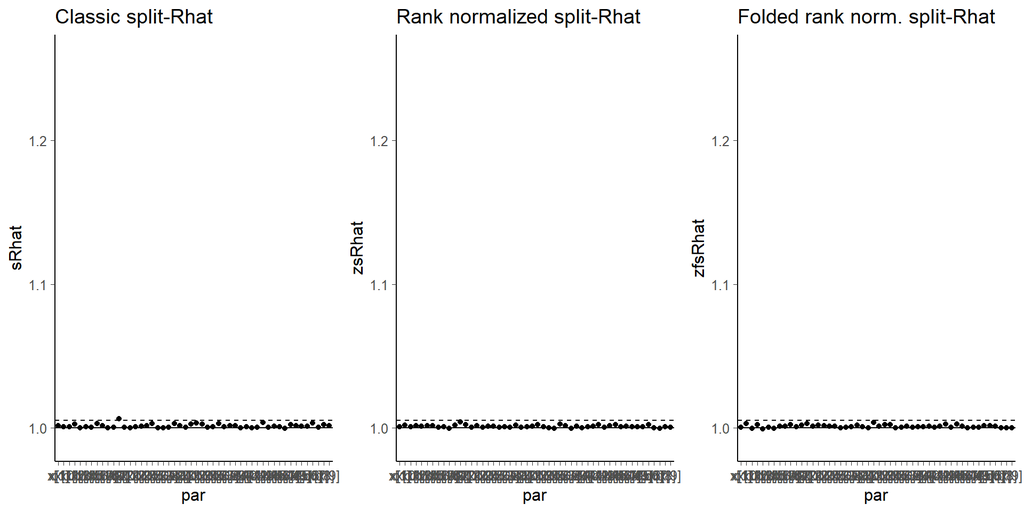

```r
plot_rhat(res)
```

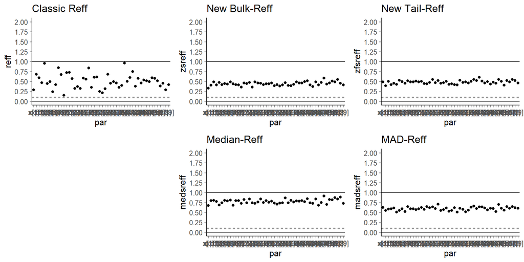

```r
plot_reff(res)
```

**Result:** The Rank normalized relative efficiencies have less variation than classic ones which is not well defined for the Cauchy distribution. Based on bulk-$R_{\rm eff}$ and median-$R_{\rm eff}$, the efficency for central quantities is much lower, but based on tail-$R_{\rm eff}$ and MAD-$R_{\rm eff}$, the efficency in the tails is slightly better than for the half-Cauchy distribution with nominal parameterization. We also see that a parameterization which is good for the full Cauchy distribution is not necessarily good for the half-Cauchy distribution as the `<lower=0>` constraint additionally changes the parameterization.

We also check the `lp__` values:

```r
res <- monitor_extra(samp[, , 151:152])
cat('lp__: Bulk-R_eff =', round(res['lp__', 'zsreff'], 2), '\n')
```

```
lp__: Bulk-R_eff = 0.24
```

```r
cat('lp__: Tail-R_eff =', round(res['lp__', 'zfsreff'], 2), '\n')
```

```
lp__: Tail-R_eff = 0.58
```

We examine the relative efficiency in different parts of the posterior by computing the relative efficiency of small interval probability estimates.

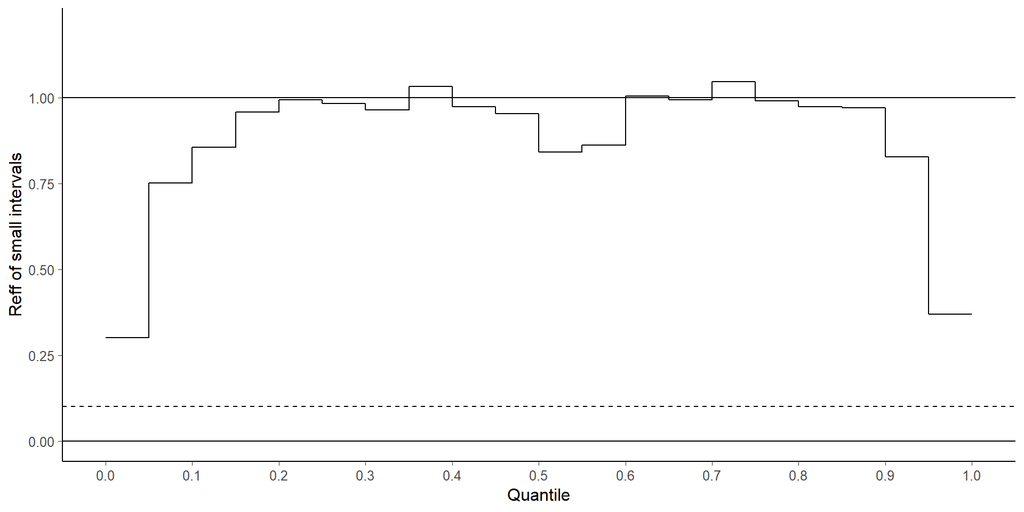

```r
plot_local_reff(fit_half_reparam, par = 100 + which_min_eff, nalpha = 20)
```

We also examine the relative efficiency of different quantile estimates.

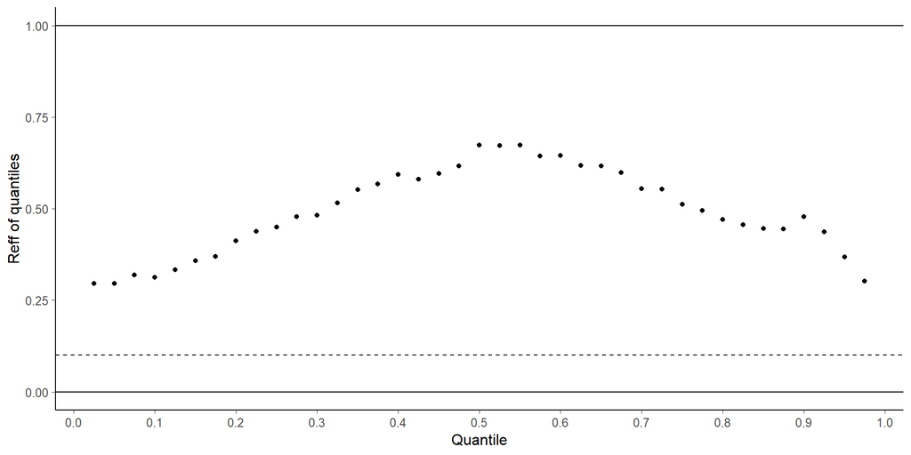

```r
plot_quantile_reff(fit_half_reparam, par = 100 + which_min_eff, nalpha = 40)
```

The relative efficiency near zero is much worse than for the half-Cauchy distribution with nominal parameterization.

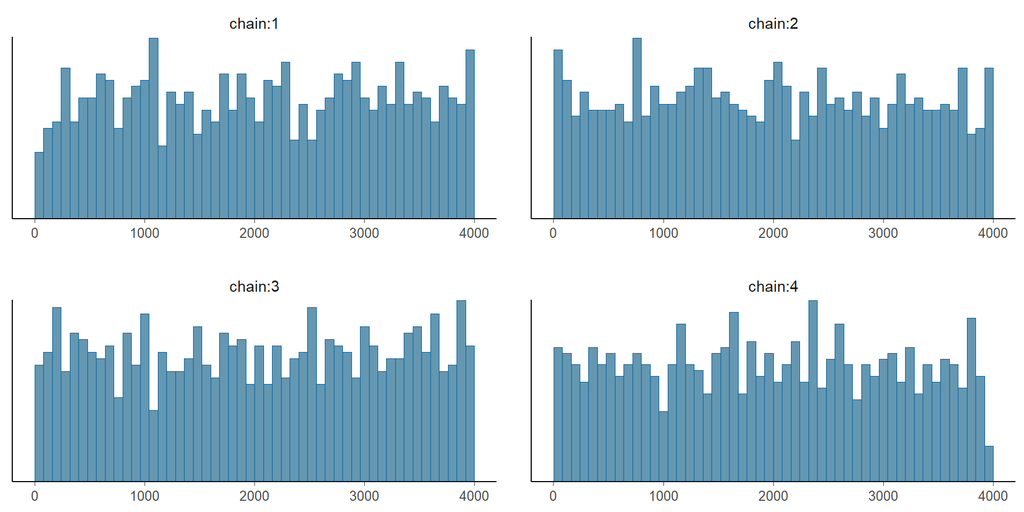

```r
xmin <- paste0("x[", which_min_eff, "]")
mcmc_hist_r_scale(samp[, , xmin])
```

A similar result is obtained when looking at the rank plots of `lp__`.

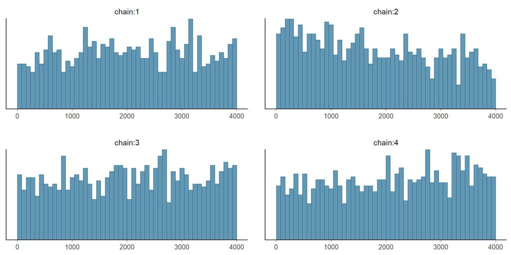

```r
mcmc_hist_r_scale(samp[, , "lp__"])
```

## Appendix F: Hierarchical model: Eight Schools

We continue with our discussion about hierarchical models on the Eight Schools data, which we started in Section Eight Schools. We also analyse the performance of of different variants of the diagnostics.

### 4.2.11 A Centered Eight Schools model

```r
writeLines(readLines("eight_schools_cp.stan"))
```

```
data {
  int<lower=0> J;
  real y[J];
  real<lower=0> sigma[J];
}

parameters {
  real mu;
  real<lower=0> tau;
  real theta[J];
}

model {
  mu ~ normal(0, 5);
  tau ~ cauchy(0, 5);
  theta ~ normal(mu, tau);
  y ~ normal(theta, sigma);
}
```

In the main text, we observed that the centered parameterization of this hierarchical model did not work well with the default MCMC options of Stan plus increased `adapt_delta`, and so we directly try to fit the model with longer chains.

#### 4.2.11.1 Centered parameterization with longer chains

Low efficiency can be sometimes compensated with longer chains. Let’s check 10 times longer chain.

```r
fit_cp2 <- stan(
  file = 'eight_schools_cp.stan', data = eight_schools,
  iter = 20000, chains = 4, seed = 483892929, refresh = 0,
  control = list(adapt_delta = 0.95)
)
res <- monitor_extra(fit_cp2)
print(res)
```

```
Inference for the input samples (4 chains: each with iter = 20000; warmup = 10000):

           mean se_mean   sd     Q5    Q50   Q95 neff reff sneff zneff zsneff zsreff Rhat sRhat
mu         4.88    0.49 3.57  -0.99   4.84 10.34   53 0.00    71    54     71   0.00 1.05  1.05
tau        3.67    0.30 3.31   0.33   2.81 10.02  123 0.00   173    35     45   0.00 1.02  1.02
theta[1]   6.76    0.22 5.64  -1.36   6.43 16.32  666 0.02  1057   281    407   0.01 1.01  1.01
theta[2]   5.42    0.43 4.80  -2.48   5.47 12.55  124 0.00   169   113    153   0.00 1.02  1.02
theta[3]   4.41    0.53 5.43  -4.92   4.66 11.52  105 0.00   146    86    117   0.00 1.03  1.02
theta[4]   5.23    0.46 4.97  -2.89   5.34 12.40  118 0.00   163   105    140   0.00 1.02  1.02
theta[5]   4.09    0.57 4.94  -4.48   4.32 10.69   76 0.00   102    69     89   0.00 1.03  1.03
theta[6]   4.49    0.51 5.08  -4.15   4.70 11.27  100 0.00   137    87    118   0.00 1.03  1.03
theta[7]   6.83    0.23 5.11  -0.88   6.60 15.53  512 0.01   745   309    449   0.01 1.01  1.01
theta[8]   5.34    0.43 5.49  -3.46   5.41 13.34  162 0.00   231   125    172   0.00 1.02  1.02
lp__     -13.84    1.32 7.59 -24.94 -14.78  0.22   33 0.00    44    37     50   0.00 1.08  1.08
         zRhat zsRhat zfsRhat zfsneff zfsreff medsneff medsreff madsneff madsreff
mu        1.05   1.05    1.02     152    0.00      174        0      174     0.00
tau       1.08   1.08    1.01    1035    0.03      175        0      167     0.00
theta[1]  1.01   1.01    1.00    3297    0.08      177        0      268     0.01
theta[2]  1.02   1.02    1.00    1817    0.05      173        0      177     0.00
theta[3]  1.03   1.03    1.01     736    0.02      168        0      172     0.00
theta[4]  1.03   1.03    1.01    1468    0.04      167        0      167     0.00
theta[5]  1.04   1.04    1.01     375    0.01      170        0      178     0.00
theta[6]  1.03   1.03    1.01     644    0.02      176        0      176     0.00
theta[7]  1.01   1.01    1.00    2761    0.07      179        0      852     0.02
theta[8]  1.02   1.02    1.00    2816    0.07      166        0      191     0.00
lp__      1.07   1.07    1.06      55    0.00      170        0      157     0.00
```

We still get a whole bunch of divergent transitions so it’s clear that the results can’t be trusted even if all other diagnostics were good. Still, it may be worth looking at additional diagnostics to better understand what’s happening.

We examine the relative efficiency in different parts of the posterior by computing the relative efficiency of small intervals for `tau`.

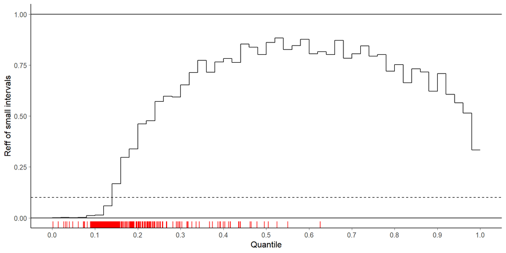

```r
plot_local_reff(fit = fit_cp2, par = "tau", nalpha = 50)
```

We see that the MCMC sampling has difficulties in exploring small `tau` values. As the efficiency for estimating small `tau` values is practically zero, we may assume that we may miss substantial amount of posterior mass and get biased estimates.

We also examine the relative efficiency of different quantile estimates.

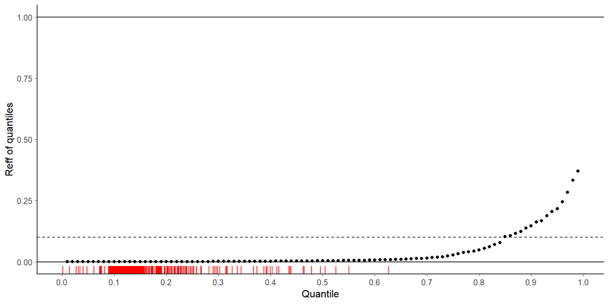

```r
plot_quantile_reff(fit = fit_cp2, par = "tau", nalpha = 100)
```

Let’s see how the estimated relative efficiency changes when we use more and more draws.

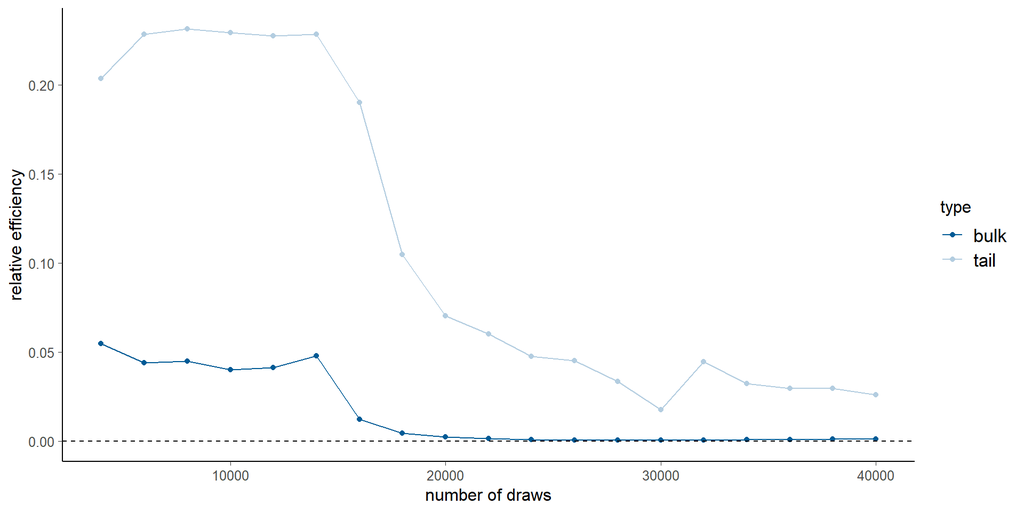

```r
plot_change_reff(fit = fit_cp2, par = "tau")
```

Most of the quantile estimates have worryingly low relative efficiency. That many of the are practically zero indicates clear failure in mixing. The rank plot visualisation of `tau` reveals substantially differences across chains.

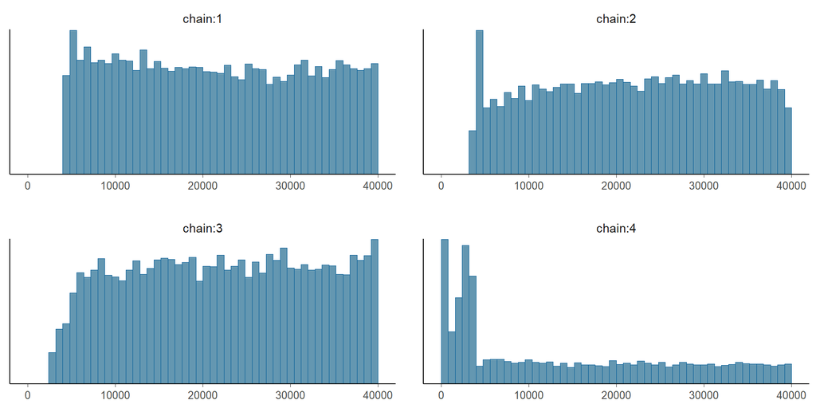

```r
samp_cp2 <- as.array(fit_cp2)
mcmc_hist_r_scale(samp_cp2[, , "tau"])
```

Similar results are obtained for `lp__`, which is closely connected to `tau` for this model.

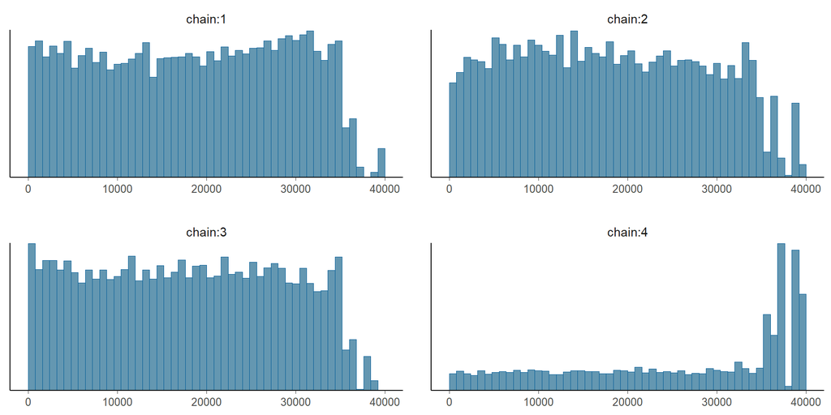

```r
mcmc_hist_r_scale(samp_cp2[, , "lp__"])
```

We may also examine small interval efficiencies for `mu`.

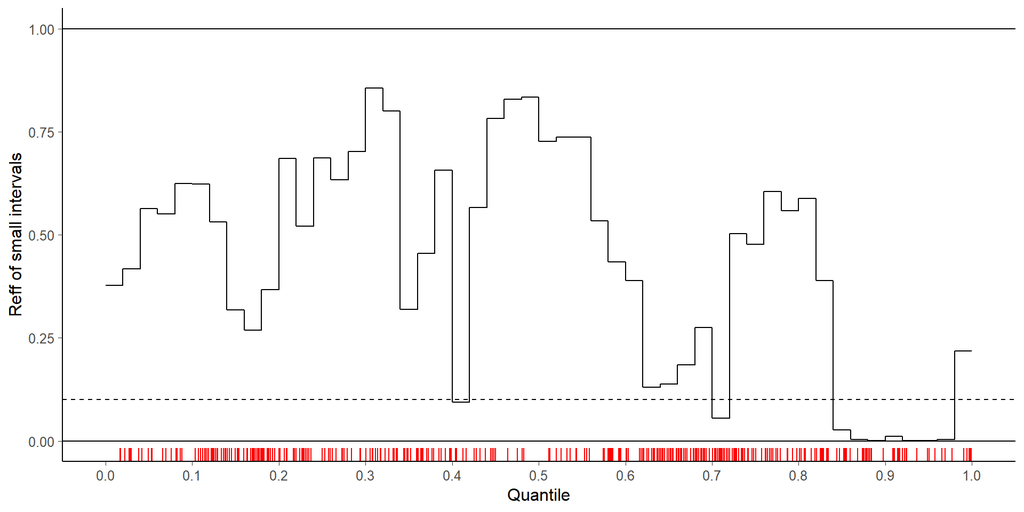

```r
plot_local_reff(fit = fit_cp2, par = "mu", nalpha = 50)
```

There are gaps of poor efficiency which again indicates problems in the mixing of the chains. However, these problems do not occur for any specific range of values of `mu` as was the case for `tau`. This tells us that it’s probably not `mu` with which the sampler has problems, but more likely `tau` or a related quantity.

As we observed divergences, we shouldn’t trust any Monte Carlo standard error (MCSE) estimates as they are likely to be biased, too. However, for illustrationary purposes, we compute the MCSE, tail quantiles and corresponding Seff for the median of `mu` and `tau`. Comparing to the shorter MCMC run, 10 times more draws has not reduced the MCSE to one third as would be expected without problems in the mixing of the chains.

```r
round(quantile_mcse(samp_cp2[ , , "mu"], prob = 0.5), 2)
```

```
  mcse  Q05  Q95   Seff
1 0.37 4.22 5.43 173.52
```

```r
round(quantile_mcse(samp_cp2[ , , "tau"], prob = 0.5), 2)
```

```
  mcse  Q05  Q95   Seff
1 0.27 2.38 3.27 174.86
```

#### 4.2.11.2 Centered parameterization with very long chains

For further evidence, let’s check 100 times longer chains than the default. This is not something we would recommend doing in practice, as it is not able to solve any problems with divergences as illustrated below.

```r
fit_cp3 <- stan(
  file = 'eight_schools_cp.stan', data = eight_schools,
  iter = 200000, chains = 4, seed = 483892929, refresh = 0,
  control = list(adapt_delta = 0.95)
)
res <- monitor_extra(fit_cp3)
print(res)
```

```
Inference for the input samples (4 chains: each with iter = 2e+05; warmup = 1e+05):

           mean se_mean   sd     Q5    Q50   Q95  neff reff sneff zneff zsneff zsreff Rhat sRhat
mu         4.37    0.02 3.33  -1.10   4.37  9.83 18435 0.05 18411 18358  18335   0.05    1     1
tau        3.80    0.03 3.21   0.47   2.94 10.04  9355 0.02  9391  2206   2200   0.01    1     1
theta[1]   6.29    0.03 5.69  -1.59   5.73 16.38 30955 0.08 31120 23846  23832   0.06    1     1
theta[2]   4.94    0.03 4.76  -2.53   4.85 12.76 32922 0.08 33013 27715  27789   0.07    1     1
theta[3]   3.87    0.02 5.36  -5.06   4.09 11.88 53609 0.13 53632 39181  39355   0.10    1     1
theta[4]   4.75    0.02 4.86  -2.95   4.68 12.64 39472 0.10 39723 32535  32607   0.08    1     1
theta[5]   3.55    0.02 4.72  -4.55   3.79 10.77 41358 0.10 41819 34256  34479   0.09    1     1
theta[6]   4.01    0.02 4.91  -4.16   4.16 11.62 45877 0.11 46105 36785  37000   0.09    1     1
theta[7]   6.38    0.03 5.16  -1.03   5.92 15.64 24701 0.06 24691 20682  20685   0.05    1     1
theta[8]   4.85    0.02 5.39  -3.49   4.74 13.51 50166 0.13 50212 36407  36212   0.09    1     1
lp__     -14.58    0.14 6.87 -24.98 -15.15 -2.08  2414 0.01  2410  2545   2541   0.01    1     1
         zRhat zsRhat zfsRhat zfsneff zfsreff medsneff medsreff madsneff madsreff
mu           1      1       1   28848    0.07    16309     0.04    18276     0.05
tau          1      1       1   32860    0.08    10904     0.03    15361     0.04
theta[1]     1      1       1   40586    0.10    15333     0.04    18846     0.05
theta[2]     1      1       1   41788    0.10    15135     0.04    18463     0.05
theta[3]     1      1       1   31386    0.08    16680     0.04    22054     0.06
theta[4]     1      1       1   38705    0.10    16525     0.04    19038     0.05
theta[5]     1      1       1   37235    0.09    16593     0.04    18887     0.05
theta[6]     1      1       1   36568    0.09    16393     0.04    18180     0.05
theta[7]     1      1       1   35129    0.09    14827     0.04    17370     0.04
theta[8]     1      1       1   38924    0.10    15431     0.04    16092     0.04
lp__         1      1       1    2942    0.01    10102     0.03    13775     0.03
```

Small interval and quantile plots of `tau` still look bad even with so many posterior samples.

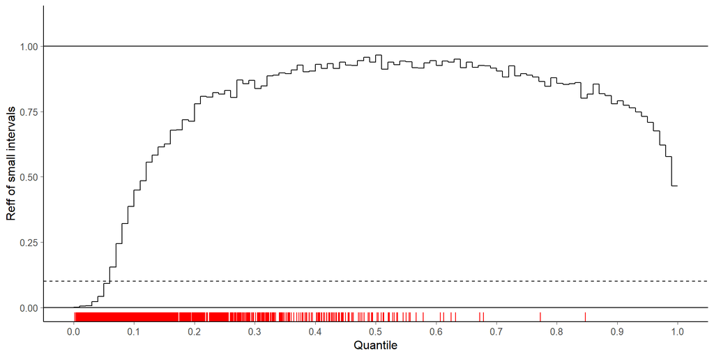

```r
plot_local_reff(fit = fit_cp3, par = "tau", nalpha = 100)
```

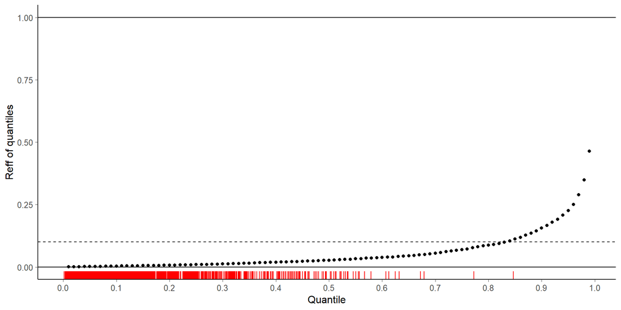

```r
plot_quantile_reff(fit = fit_cp3, par = "tau", nalpha = 100)
```

Same for the rank plots of `tau`.

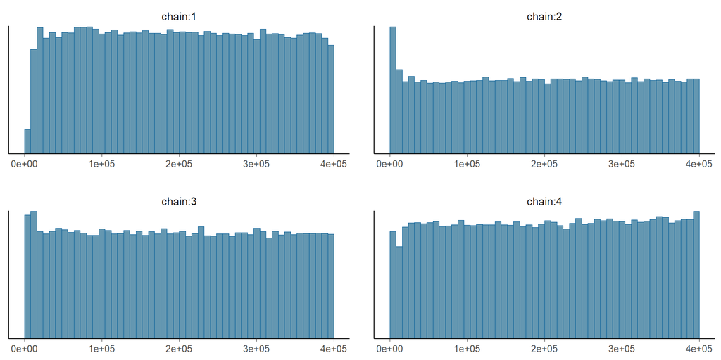

```r
samp_cp3 <- as.array(fit_cp3)
mcmc_hist_r_scale(samp_cp3[, , "tau"])
```

What we do see is an advantage of rank plots over trace plots as even with 100000 draws per chain, rank plots don’t get crowded and slow mixing of chains is still easy to see.

### 4.2.12 Non-centered Eight Schools model

In the following, we want to expand our understanding of the non-centered parameterization of the hierachical model fit to the eight schools data.

```r
writeLines(readLines("eight_schools_ncp.stan"))
```

```
data {
  int<lower=0> J;
  real y[J];
  real<lower=0> sigma[J];
}

parameters {
  real mu;
  real<lower=0> tau;
  real theta_tilde[J];
}

transformed parameters {
  real theta[J];
  for (j in 1:J)
    theta[j] = mu + tau * theta_tilde[j];
}

model {
  mu ~ normal(0, 5);
  tau ~ cauchy(0, 5);
  theta_tilde ~ normal(0, 1);
  y ~ normal(theta, sigma);
}
```

#### 4.2.12.1 Non-centered parameterization with default MCMC options

In the main text, we have already seen that the non-centered parameterization works better than the centered parameterization, at least when we use an increased `adapt_delta` vaue. Let’s see what happens when using the default MCMC option of Stan.

```r
fit_ncp <- stan(
  file = 'eight_schools_ncp.stan', data = eight_schools,
  iter = 2000, chains = 4, seed = 483892929, refresh = 0
)
```

We observe a few divergent transitions with the default of `adapt_delta=0.8`. Let’s analyze the sample.

```r
res <- monitor_extra(fit_ncp)
print(res)
```

```
Inference for the input samples (4 chains: each with iter = 2000; warmup = 1000):

                mean se_mean   sd     Q5   Q50   Q95 neff reff sneff zneff zsneff zsreff Rhat sRhat
mu              4.38    0.05 3.24  -0.98  4.41  9.52 4023 1.01  4036  4070   4083   1.02    1     1
tau             3.61    0.06 3.16   0.25  2.77  9.77 2684 0.67  2700  2293   2303   0.58    1     1
theta_tilde[1]  0.32    0.01 0.97  -1.31  0.35  1.88 4528 1.13  4566  4532   4571   1.14    1     1
theta_tilde[2]  0.12    0.01 0.92  -1.41  0.14  1.64 5742 1.44  5758  5754   5771   1.44    1     1
theta_tilde[3] -0.09    0.01 0.96  -1.62 -0.10  1.49 4929 1.23  4974  4919   4966   1.24    1     1
theta_tilde[4]  0.05    0.01 0.91  -1.43  0.03  1.51 5370 1.34  5436  5376   5442   1.36    1     1
theta_tilde[5] -0.16    0.01 0.91  -1.67 -0.17  1.35 4222 1.06  4269  4226   4273   1.07    1     1
theta_tilde[6] -0.07    0.01 0.95  -1.64 -0.08  1.48 5182 1.30  5195  5179   5192   1.30    1     1
theta_tilde[7]  0.36    0.02 0.97  -1.25  0.39  1.88 3885 0.97  3888  3893   3898   0.97    1     1
theta_tilde[8]  0.08    0.01 0.97  -1.51  0.07  1.68 4838 1.21  4853  4834   4848   1.21    1     1
theta[1]        6.27    0.09 5.60  -1.38  5.68 15.84 3504 0.88  3530  3767   3790   0.95    1     1
theta[2]        5.03    0.07 4.62  -2.29  4.88 12.83 4892 1.22  4928  4965   5002   1.25    1     1
theta[3]        3.95    0.09 5.24  -4.28  4.08 11.90 3796 0.95  3825  3971   4001   1.00    1     1
theta[4]        4.64    0.07 4.63  -2.74  4.66 12.09 4554 1.14  4577  4676   4699   1.17    1     1
theta[5]        3.63    0.07 4.54  -4.13  3.89 10.45 4126 1.03  4174  4258   4310   1.08    1     1
theta[6]        3.95    0.07 4.88  -4.11  4.19 11.30 4726 1.18  4815  4922   4965   1.24    1     1
theta[7]        6.28    0.07 4.94  -0.84  5.86 15.18 4416 1.10  4423  4524   4599   1.15    1     1
theta[8]        4.91    0.08 5.37  -3.24  4.77 13.52 4046 1.01  4066  4439   4461   1.12    1     1
lp__           -6.81    0.06 2.30 -11.06 -6.47 -3.68 1678 0.42  1684  1704   1711   0.43    1     1
               zRhat zsRhat zfsRhat zfsneff zfsreff medsneff medsreff madsneff madsreff
mu                 1      1       1    1775    0.44     4237     1.06     2343     0.59
tau                1      1       1    3132    0.78     3151     0.79     3171     0.79
theta_tilde[1]     1      1       1    2141    0.54     4489     1.12     2491     0.62
theta_tilde[2]     1      1       1    1984    0.50     5350     1.34     2406     0.60
theta_tilde[3]     1      1       1    2136    0.53     5397     1.35     2447     0.61
theta_tilde[4]     1      1       1    2008    0.50     4821     1.21     2419     0.60
theta_tilde[5]     1      1       1    2263    0.57     4282     1.07     2692     0.67
theta_tilde[6]     1      1       1    2078    0.52     4760     1.19     2412     0.60
theta_tilde[7]     1      1       1    2260    0.57     3823     0.96     2783     0.70
theta_tilde[8]     1      1       1    1905    0.48     4351     1.09     2000     0.50
theta[1]           1      1       1    2528    0.63     4358     1.09     2788     0.70
theta[2]           1      1       1    2302    0.58     4229     1.06     2542     0.64
theta[3]           1      1       1    2553    0.64     4002     1.00     2971     0.74
theta[4]           1      1       1    2654    0.66     4548     1.14     2859     0.71
theta[5]           1      1       1    2783    0.70     4523     1.13     2689     0.67
theta[6]           1      1       1    2666    0.67     4759     1.19     3152     0.79
theta[7]           1      1       1    2493    0.62     4315     1.08     2911     0.73
theta[8]           1      1       1    2472    0.62     4400     1.10     2644     0.66
lp__               1      1       1    2487    0.62     1990     0.50     2796     0.70
```

All Rhats are close to 1, and relative efficiencies are good despite a few divergent transitions. Small interval and quantile plots of `tau` reveal some sampling problems for small `tau` values, but not nearly as strong as for the centered parameterization.

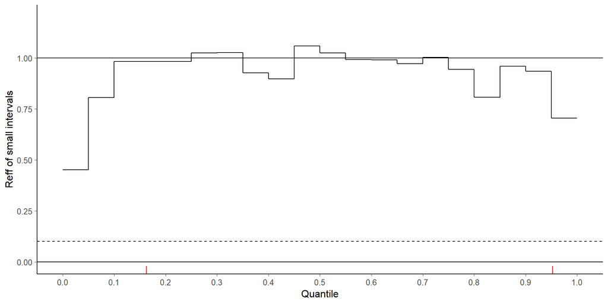

```r
plot_local_reff(fit = fit_ncp, par = "tau", nalpha = 20)
```

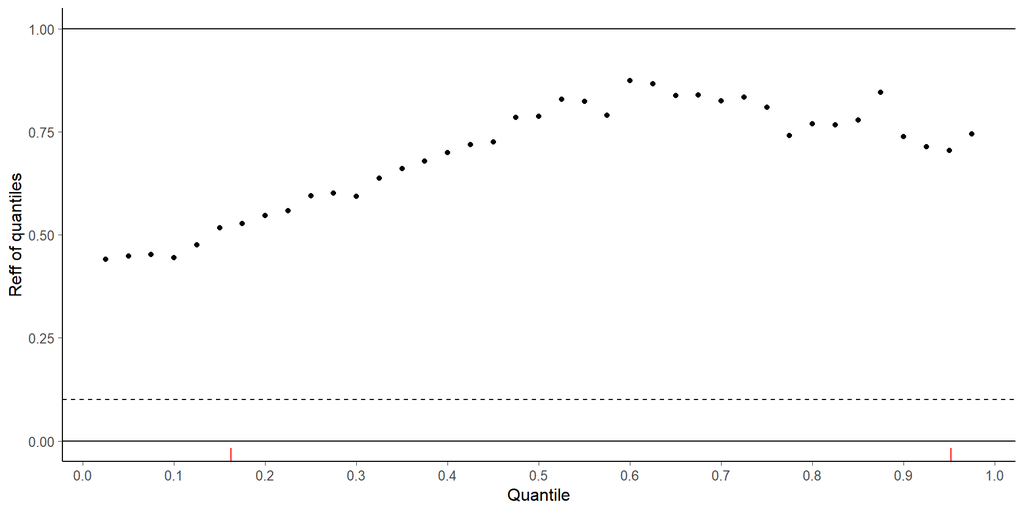

```r
plot_quantile_reff(fit = fit_ncp, par = "tau", nalpha = 40)
```

Overall, the non-centered parameterization looks good even for the default settings of `adapt_delta`, and increasing it to 0.95 gets rid of the last remaining problems. This stands in sharp contrast to what we observed for the centered parameterzation, where increasing `adapt_delta` didn’t help at all. Actually, this is something we observe quite often: A suboptimal parameterization can cause problems that are not simply solved by tuning the sampler. Instead, we have to adjust our model to achieve trustworthy inference.

## Appendix G: Dynamic HMC and effective sample size

We have already seen that the relative efficiency of dynamic HMC can be higher than with independent draws. The next example illustrates interesting relative efficiency phenomena due to the properties of dynamic HMC algorithms.

We sample from a simple 16-dimensional standard normal model.

```r
writeLines(readLines("normal.stan"))
```

```
data {
  int<lower=1> J;
}
parameters {
  vector[J] x;
}
model {
  x ~ normal(0, 1);
}
```

```r
fit_n <- stan(
  file = 'normal.stan', data = data.frame(J = 16),
  iter = 20000, chains = 4, seed = 483892929, refresh = 0
)
```

```r
samp <- as.array(fit_n)
res <- monitor_extra(samp)
print(res)
```

```
Inference for the input samples (4 chains: each with iter = 10000; warmup = 0):

       mean se_mean   sd     Q5   Q50   Q95   neff reff  sneff  zneff zsneff zsreff Rhat sRhat
x[1]   0.00    0.00 1.00  -1.66  0.00  1.65  97846 2.45  98426  97687  98264   2.46    1     1
x[2]   0.00    0.00 1.00  -1.64 -0.01  1.64  95437 2.39  95717  95531  95812   2.40    1     1
x[3]   0.00    0.00 0.99  -1.63  0.00  1.62  98375 2.46  98703  98313  98640   2.47    1     1
x[4]   0.01    0.00 1.01  -1.65  0.00  1.66  96642 2.42  97290  96654  97302   2.43    1     1
x[5]   0.00    0.00 1.00  -1.64  0.00  1.63 101317 2.53 101514 101344 101542   2.54    1     1
x[6]   0.00    0.00 1.00  -1.65  0.00  1.65  96011 2.40  96299  96003  96292   2.41    1     1
x[7]   0.00    0.00 0.99  -1.63  0.01  1.63  95558 2.39  96082  95492  96016   2.40    1     1
x[8]   0.00    0.00 1.00  -1.65 -0.01  1.65  99937 2.50 100392  99920 100375   2.51    1     1
x[9]   0.00    0.00 1.00  -1.64  0.01  1.65 100824 2.52 101134 100831 101141   2.53    1     1
x[10]  0.00    0.00 0.99  -1.62 -0.01  1.63 102178 2.55 102983 102317 103126   2.58    1     1
x[11]  0.00    0.00 1.00  -1.65  0.01  1.66  95226 2.38  95863  95250  95886   2.40    1     1
x[12]  0.01    0.00 0.99  -1.62  0.00  1.63  97828 2.45  98357  97903  98433   2.46    1     1
x[13]  0.00    0.00 0.99  -1.62  0.01  1.65  97666 2.44  98166  97682  98181   2.45    1     1
x[14]  0.00    0.00 0.99  -1.63  0.00  1.63  96805 2.42  97327  96792  97313   2.43    1     1
x[15]  0.01    0.00 0.99  -1.63  0.01  1.64  94911 2.37  95185  94950  95223   2.38    1     1
x[16]  0.00    0.00 1.01  -1.66  0.00  1.65  99541 2.49 100111  99413  99980   2.50    1     1
lp__  -7.95    0.02 2.79 -13.00 -7.66 -3.92  14922 0.37  14934  14480  14489   0.36    1     1
      zRhat zsRhat zfsRhat zfsneff zfsreff medsneff medsreff madsneff madsreff
x[1]      1      1       1   16450    0.41    82432     2.06    19205     0.48
x[2]      1      1       1   16462    0.41    75494     1.89    19208     0.48
x[3]      1      1       1   16152    0.40    78630     1.97    18732     0.47
x[4]      1      1       1   16075    0.40    81148     2.03    19079     0.48
x[5]      1      1       1   16785    0.42    79953     2.00    20116     0.50
x[6]      1      1       1   16578    0.41    79018     1.98    19626     0.49
x[7]      1      1       1   17109    0.43    81690     2.04    19543     0.49
x[8]      1      1       1   16400    0.41    79263     1.98    18828     0.47
x[9]      1      1       1   15890    0.40    81119     2.03    18683     0.47
x[10]     1      1       1   16460    0.41    76948     1.92    19242     0.48
x[11]     1      1       1   15969    0.40    79164     1.98    18329     0.46
x[12]     1      1       1   15294    0.38    81841     2.05    18720     0.47
x[13]     1      1       1   15370    0.38    80615     2.02    18210     0.46
x[14]     1      1       1   16452    0.41    77592     1.94    19050     0.48
x[15]     1      1       1   16651    0.42    80406     2.01    19622     0.49
x[16]     1      1       1   16395    0.41    82347     2.06    18845     0.47
lp__      1      1       1   21484    0.54    17074     0.43    23603     0.59
```

The Bulk-$R_{\rm eff}$ for all $x$ is larger than 2.38. However tail-$R_{\rm eff}$ for all $x$ is less than 0.43. Further, bulk-$R_{\rm eff}$ for `lp__` is only 0.36.  
If we take a look at all the Stan examples in this notebook, we see that the bulk-$R_{\rm eff}$ for `lp__` is always below 0.5. This is because `lp__` correlates strongly with the total energy in HMC, which is sampled using a random walk proposal once per iteration. Thus, it’s likely that `lp__` has some random walk behavior, as well, leading to autocorrelation and a small relative efficiency. At the same time, adaptive HMC can create antithetic Markov chains which have negative auto-correlations at odd lags. This results in a bulk relative efficiency of greater than 1 for some parameters.

Let’s check the relative efficiency in different parts of the posterior by computing the relative efficiency of small interval estimates for `x[1]`.

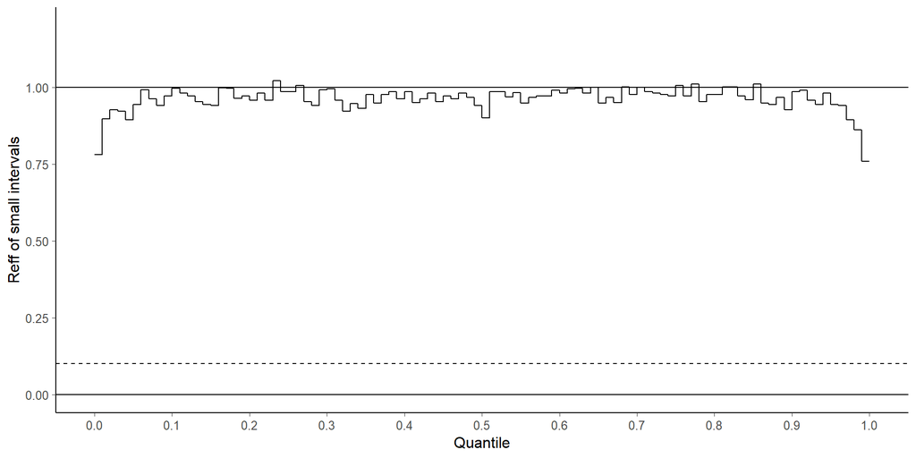

```r
plot_local_reff(fit_n, par = 1, nalpha = 100)
```

The relative efficiency for probability estimate for a small interval is close to 1 with a slight drop in the tails. This is a good result, but far from the relative efficiency for the bulk, mean, and median estimates. Let’s check the relative efficiency of quantiles.

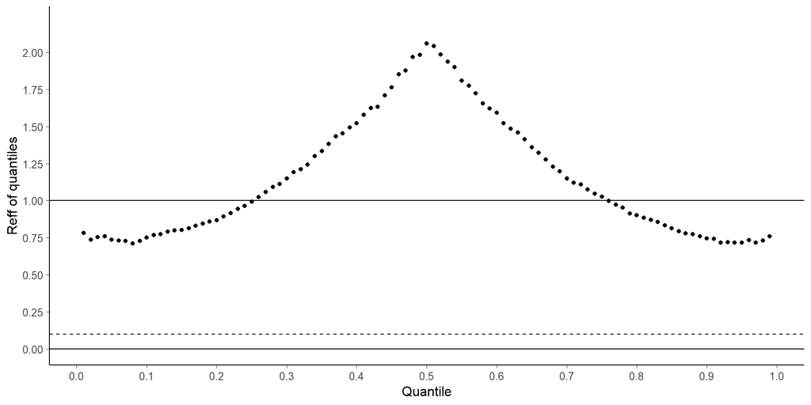

```r
plot_quantile_reff(fit = fit_n, par = 1, nalpha = 100)
```

Central quantile estimates have higher relative efficiency than tail quantile estimates.